# Ennustava kunnossapito - Demo

Samuli Reinikainen

10.6.2019

# 1 Johdanto

Tämän notebookin tarkoitus on demota yleistä kunnossapidon ennustamisen käyttötapausta koneoppimisen näkökulmasta. Demo pohjautuu vahvasti Microsoft Azure AI:n vastaavan [demoon](https://gallery.azure.ai/Notebook/Predictive-Maintenance-Modelling-Guide-R-Notebook-1). Datana käytetään samaisesta lähteestä peräisin olevaa simuloitua kunnossapidon dataa, joka on saataville muun muassa [täältä](https://www.kaggle.com/yuansaijie0604/xinjiang-pm). Tavoitteena on ennustaa laitteen hajoaminen.

```r
starttime = Sys.time()
set.seed(100)
## Käytetyt paketit
library(tidyverse)
library(caret)
library(data.table)
library(zoo)
library(lubridate)
library(knitr)
library(kableExtra)
library(gridExtra)
library(ggpubr)
library(tidyquant)
library(corrplot)
library(class)
library(rattle)
library(ggsci)
```

# 2 Data

PdM käyttötapauksissa käytettävissä oleva data on usein jakautuneena useisiin tauluihin esim. EAM-ohjelmiston tietokannassa.  
Hyödyllistä dataa ovat mm.

- Huoltohistoria
- Vikahistoria
- Käyttöhistoria
- IoT-mittausdata
- Laitteiden metatiedot

Data voidaan jakaa staattiseen, eli pysyvään dataan ja temporaaliseen, eli ajasta riippuvaiseen dataan. Staattista dataa ovat mm. laitteen malli ja temporaalista dataa vikahistoria ja mittausdata.

Tässä demossa käytettävässä aineistossa on huolto-, vika-, IoT-, ja metatietoja sadasta laitteesta aikaväliltä 1.1.2015 - 1.1.2016. Laitteilla on neljä eri mallia ja niillä on yhteensä neljä erilaista vikaantuvaa komponenttia. Lisäksi laitteista on tiedossa niiden iät. Laitteista on mitattu tunnin välein neljä eri suuretta: tärinä, paine, jännite ja pyörimisnopeus. Laitteilla on kahdenlaista vioittumisdataa: virheilmoitukset ja viat. Virheilmoitukset ovat laitteen tuottamia ilmoituksia väliaikaisista häiriöistä, jotka eivät kuitenkaan johda laitteen pysähtymiseen. Viat viittavat laitteen hajoamiseen toimintakyvyttömäksi ja liittyvät aina tiettyyn komponenttiin. Laitteiden huoltodata sisältää sekä ennakkohuoltoja, että korjauksia, mutta niitä ei ole eritelty. Kaikki huollot liittyvät yhteen komponenttiin.

Data on viidessä eri csv-tiedostossa ja ne luetaan R-ympäristöön viiteen eri tauluun.

```r
Virheet = read.csv("Data//PdM_errors.csv", header = T, stringsAsFactors = F)
Viat = read.csv("Data//PdM_failures.csv", header = T, stringsAsFactors = F)
Laitteet = read.csv("Data//PdM_machines.csv", header = T, stringsAsFactors = F)
Huollot = read.csv("Data//PdM_maint.csv", header = T, stringsAsFactors = F)
IoT = read.csv("Data//telemetry2.csv", header = T, stringsAsFactors = F)

# Muokataan nimet kuvaavammiksi ja parsitaan aikaobjektit

names(Virheet) = c("aikaleima", "laiteID", "virheID")
names(Huollot) = c("aikaleima", "laiteID", "komponentti")
names(IoT) = c("aikaleima", "laiteID", "jännite", "pyörimisnopeus", "paine", "tärinä")
names(Laitteet) = c("laiteID", "malli", "ikä")
names(Viat) = c("aikaleima", "laiteID", "komponentti")
Huollot = Huollot %>% mutate(aikaleima = ymd_hms(aikaleima))
Viat = Viat %>% mutate(aikaleima = ymd_hms(aikaleima))
Virheet = Virheet %>% mutate(aikaleima = ymd_hms(aikaleima))
IoT = IoT %>% mutate(aikaleima = ymd_hms(aikaleima))

## Funktioita myöhempään käyttöön

# Printtaa data.framen nätisti
customDfRender = function(df, scroll = F) {
  if(!scroll) {
    df %>%
      kable(align = rep("c",25)) %>%
      kable_styling(bootstrap_options = c("hover", "condensed"))
  }
  else {
    df %>%
      kable(align = rep("c",25)) %>%
      kable_styling(bootstrap_options = c("hover", "condensed")) %>%
      scroll_box(width = "100%")
  }
}

## Confusion matrix grafiikka
plotconf = function(x) {
  x = x$table
  y = as.data.frame(x)$Freq
  sums = colSums(x)
  for(i in 1:ncol(x)) {
    x[,i] = x[,i]/sums[i]
  }
  x = as.data.frame(x)
  x = mutate(x, Prosenttia = Freq, Freq = y)
  tile <- ggplot() +
  geom_tile(aes(x=Reference, y=Prediction,fill=Prosenttia),data=x, color="black",size=0.1) +
  labs(x="Oikea luokka",y="Ennustettu luokka")
  tile = tile +
  geom_text(
    aes(
      x=Reference,
      y=Prediction,
      label= paste(Freq, paste("(", paste(round(Prosenttia,2)*100, "%"), ")", sep = ""))),
    data=x,
    size=3,
    colour="black") +
  scale_fill_gradient(low="grey",high="steelblue")

  tile = tile +
  geom_tile(
    aes(x=Reference,y=Prediction),
    data=subset(x, as.character(Reference)==as.character(Prediction)),
    color="black",
    size=0.3,
    fill="black",
    alpha=0)
  tile
}
```

## 2.1 Laitteet

Laitteita on sata ja jokaisella laitteella on uniikki ID. Malli on kategorinen muuttuja, jolla on luokat *model1*, *model2*, *model3* ja *model4*. Ikä on numeerinen muuttuja ja mitattu vuosissa. Kymmenen ensimmäisen laitteen osalta data näyttää tältä:

```r
head(Laitteet, 10) %>% customDfRender()
```

| laiteID | malli | ikä |
| --- | --- | --- |
| 1 | model3 | 18 |
| 2 | model4 | 7 |
| 3 | model3 | 8 |
| 4 | model3 | 7 |
| 5 | model3 | 2 |
| 6 | model3 | 7 |
| 7 | model3 | 20 |
| 8 | model3 | 16 |
| 9 | model4 | 7 |
| 10 | model3 | 10 |

Mallien ja iän jakaumat näyttävät tältä

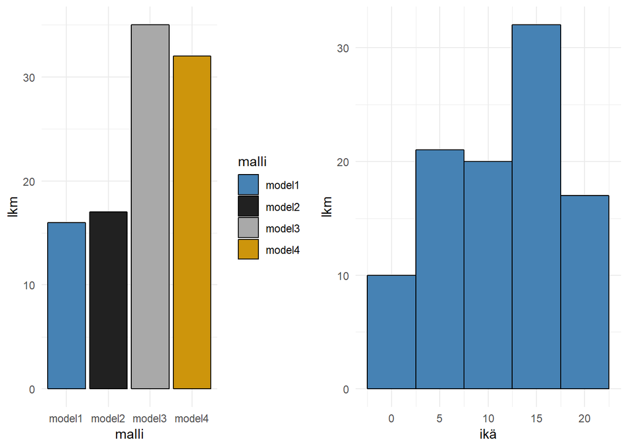

```r
custom.col <- c("steelblue", "grey13", "darkgrey", "darkgoldenrod3", "darkgreen")
g1 = ggplot(Laitteet, aes(malli)) +
  geom_bar(color = "black", aes(fill = malli)) +
  theme_minimal() +
  ylab("lkm") +
  scale_fill_manual(values = custom.col)
g2 = ggplot(Laitteet, aes(ikä)) +
  geom_histogram(binwidth = 5, color = "black", fill = "steelblue") +
  theme_minimal() +
  ylab("lkm") +
  scale_fill_manual(values = custom.col)
grid.arrange(g1, g2, ncol = 2)
```

Malleittainen ikäjakauma näyttää, että mallin 1 laitteet ovat keskimäärin vanhimipia ja mallin 4 uusimpia.

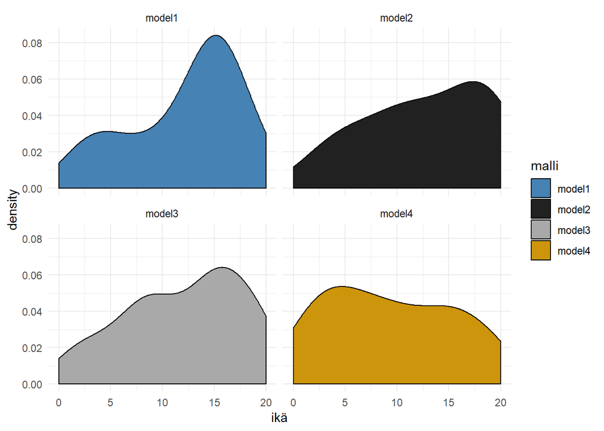

```r
ggplot(Laitteet, aes(x = ikä, fill = malli)) +
  geom_density()  +
  facet_wrap(~malli) +
  theme_minimal() +
  scale_fill_manual(values = custom.col)
```

## 2.2 Viat

Vikahavaintoja on 761. Jokaisella vialla on aikaleima, joka on asetettu vian tapahtumispäivän aamuun klo 06:00, laiteID, jolle vika tapahtui ja komponentti, jota vika koski. Kymmenen ensimmäistä vikaa näyttävät tältä

```r
head(Viat, 10) %>% customDfRender()
```

| aikaleima | laiteID | komponentti |
| --- | --- | --- |
| 2015-01-05 06:00:00 | 1 | comp4 |
| 2015-03-06 06:00:00 | 1 | comp1 |
| 2015-04-20 06:00:00 | 1 | comp2 |
| 2015-06-19 06:00:00 | 1 | comp4 |
| 2015-09-02 06:00:00 | 1 | comp4 |
| 2015-10-17 06:00:00 | 1 | comp2 |
| 2015-12-16 06:00:00 | 1 | comp4 |
| 2015-03-19 06:00:00 | 2 | comp1 |
| 2015-03-19 06:00:00 | 2 | comp2 |
| 2015-04-18 06:00:00 | 2 | comp2 |

Vikojen jakauma komponentittain kertoo, että komponentti kaksi on yleisin vikaantuja.

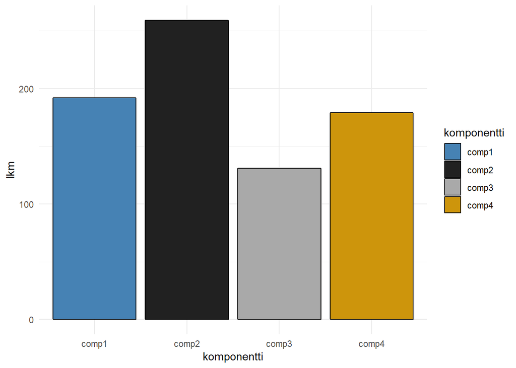

```r
ggplot(Viat, aes(x = komponentti)) +
  geom_bar(color = "black", aes(fill = komponentti)) +
  ylab("lkm") +
  theme_minimal() +
  scale_fill_manual(values = custom.col)
```

Komponenttien vikojen aikajakaumasta nähdään, että selvää kokonaistrendiä vikatiheydessä ei ole.

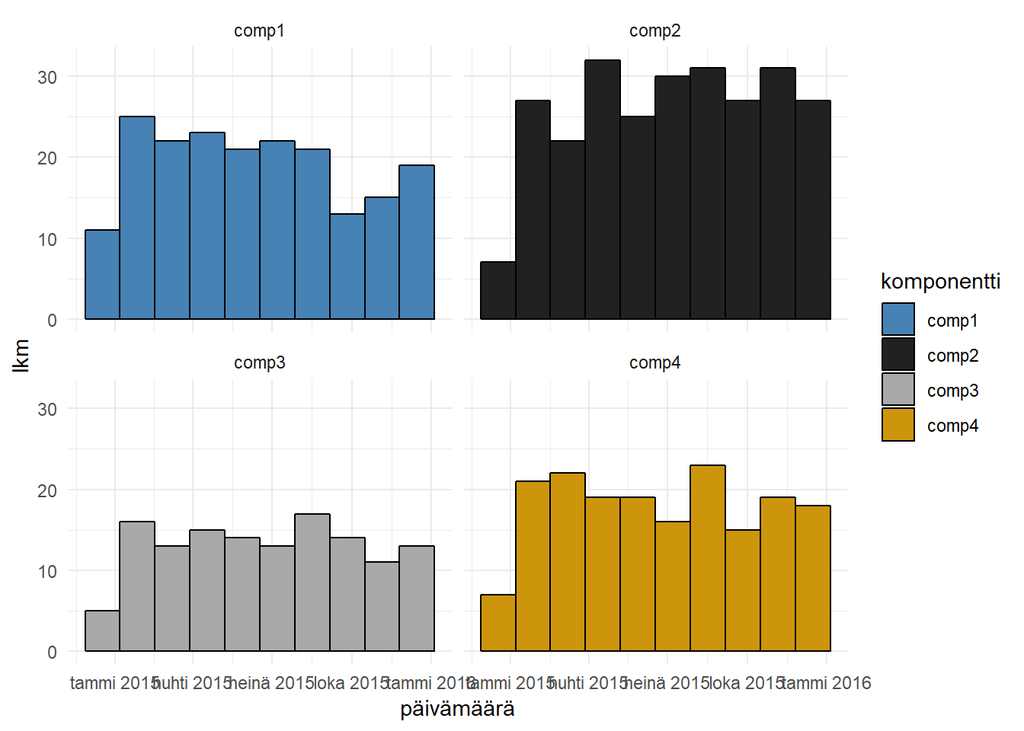

```r
ggplot(Viat, aes(x = aikaleima)) +
  geom_histogram(bins = 10, color = "black", aes(fill = komponentti)) +
  ylab("lkm") +
  xlab("päivämäärä") +
  facet_wrap(~komponentti) +
  theme_minimal() +
  scale_fill_manual(values = custom.col)
```

Komponenttien vikajakauma malleittain paljastaa, ettei mallia 3 tai 4 olevien laitteiden komponentti 3 ole vikaantunut kertaakaan tarkastelujaksolla, kun taas mallien 1 ja 2 kohdalla se on yleisimmin vikaantuva komponentti.

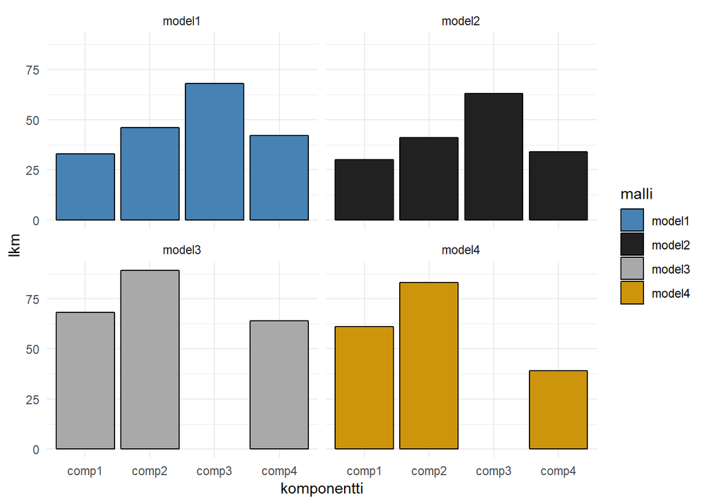

```r
ggplot(Viat %>% left_join(Laitteet, by = "laiteID"), aes(x = komponentti, fill = malli)) +
  geom_bar(color = "black") +
  ylab("lkm") +
  facet_wrap(~malli) +
  theme_minimal() +
  scale_fill_manual(values = custom.col)
```

## 2.3 Virheet

Virhehavaintoja on 3919. Jokaisesta on talletettu aikaleima tunnin tarkkuudella, laiteID, jota virhe koskee, sekä virhetyypin ID. Tässä kymmenen ensimmäistä virhettä

```r
head(Virheet, 10) %>%  customDfRender()
```

| aikaleima | laiteID | virheID |
| --- | --- | --- |
| 2015-01-03 07:00:00 | 1 | error1 |
| 2015-01-03 20:00:00 | 1 | error3 |
| 2015-01-04 06:00:00 | 1 | error5 |
| 2015-01-10 15:00:00 | 1 | error4 |
| 2015-01-22 10:00:00 | 1 | error4 |
| 2015-01-25 15:00:00 | 1 | error4 |
| 2015-01-27 04:00:00 | 1 | error1 |
| 2015-03-03 22:00:00 | 1 | error2 |
| 2015-03-05 06:00:00 | 1 | error1 |
| 2015-03-20 18:00:00 | 1 | error1 |

Virhetyyppien lukumääräjakauma osoittaa, että virheet on numeroitu yleisyyden mukaan.

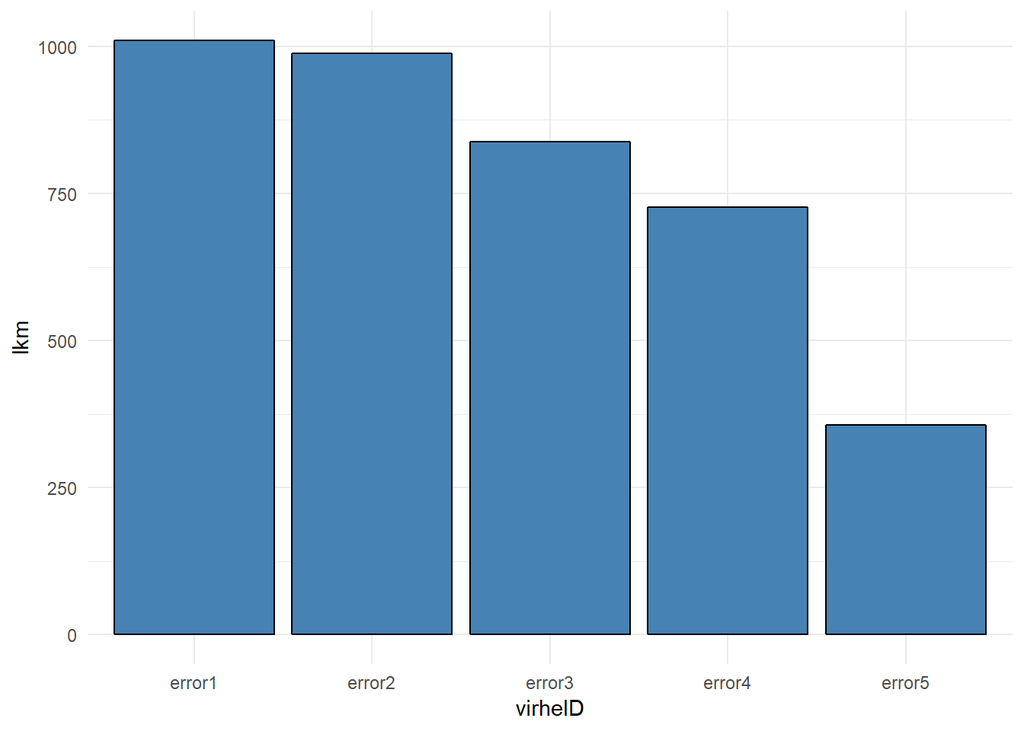

```r
ggplot(Virheet, aes(virheID)) +
  geom_bar(color = "black", fill = "steelblue") +
  ylab("lkm") +
  theme_minimal()
```

Virhetyyppien jakauma malleittain näyttää tältä.

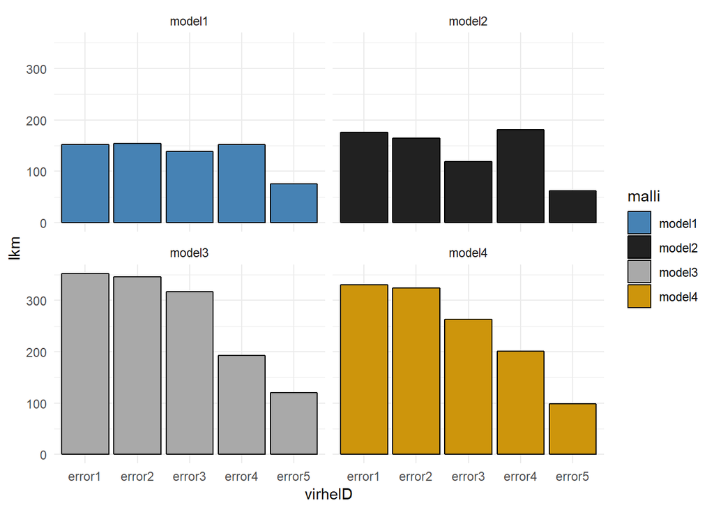

```r
ggplot(Virheet %>% left_join(Laitteet, by = "laiteID"), aes(virheID)) +
  geom_bar(aes(fill = malli), color = "black") +
  facet_wrap(~malli) +
  ylab("lkm") +
  theme_minimal() +
  scale_fill_manual(values = custom.col)
```

Mallien 1 ja 2 virhejakaumat ovat tasaisempia kuin mallien 3 ja 4. Mallien kokonaisjakaumaan suhteutettuna virheiden kokonaismäärät malleittain näyttävät tasaisilta.

## 2.4 Huollot

Huoltoja on 3286. Jokaisesta on tallennettu aikaleima, joka on asetettu kyseisen päivän aamuun klo 06:00 aivan kuten vioilla, laiteID, jota huolto koskee ja komponentti, jota huollettiin.

```r
head(Huollot, 10) %>% customDfRender()
```

| aikaleima | laiteID | komponentti |
| --- | --- | --- |
| 2014-06-01 06:00:00 | 1 | comp2 |
| 2014-07-16 06:00:00 | 1 | comp4 |
| 2014-07-31 06:00:00 | 1 | comp3 |
| 2014-12-13 06:00:00 | 1 | comp1 |
| 2015-01-05 06:00:00 | 1 | comp4 |
| 2015-01-05 06:00:00 | 1 | comp1 |
| 2015-01-20 06:00:00 | 1 | comp3 |
| 2015-01-20 06:00:00 | 1 | comp1 |
| 2015-02-04 06:00:00 | 1 | comp4 |
| 2015-02-04 06:00:00 | 1 | comp3 |

Komponenttien huoltojen jakauma näyttää, että komponentteja on huollettu tasaisesti.

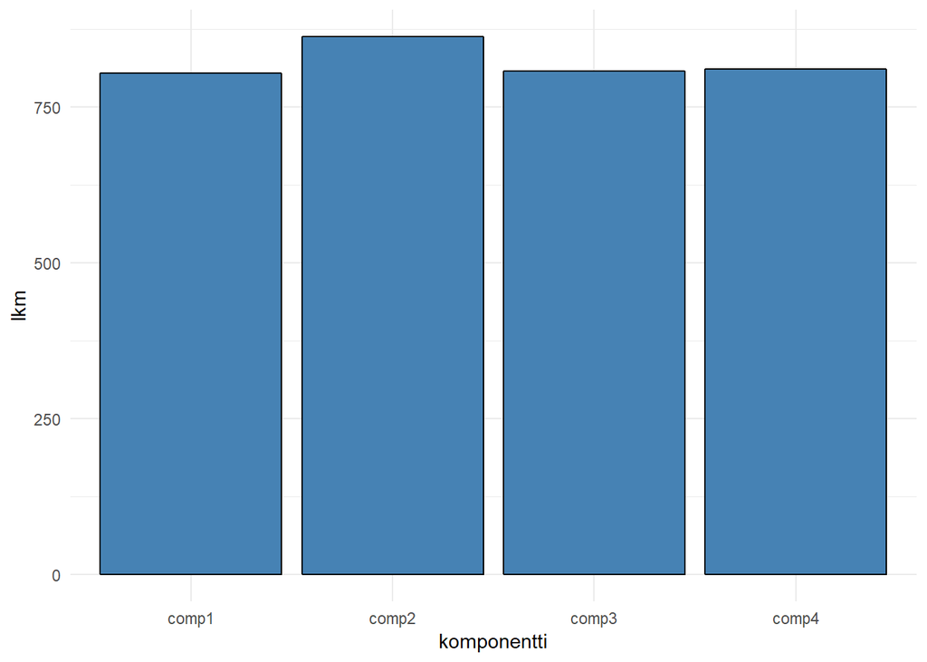

```r
ggplot(Huollot, aes(komponentti)) +
  geom_bar(fill = "steelblue", color = "black") +
  ylab("lkm") +
  theme_minimal()
```

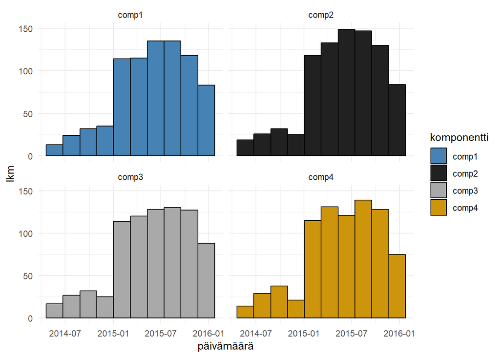

```r
ggplot(Huollot, aes(aikaleima)) +
  geom_histogram(bins = 10, color = "black", aes(fill = komponentti)) +
  facet_wrap(~komponentti) +
  ylab("lkm") +
  xlab("päivämäärä") +
  theme_minimal() +
  scale_fill_manual(values = custom.col)
```

## 2.5 IoT

IoT mittauksia on yhteensä 876100 jokaista suuretta kohti. Varsinaisen suureen arvon lisäksi on tallennettu aikaleima tunnin tarkkuudella sekä mitatun laitteen ID. Kymmenen ensimmäistä havaintoa näyttävät tältä

```r
head(IoT, 10) %>% customDfRender()
```

| aikaleima | laiteID | jännite | pyörimisnopeus | paine | tärinä |
| --- | --- | --- | --- | --- | --- |
| 2015-01-01 06:00:00 | 1 | 176.2179 | 418.5041 | 113.07794 | 45.08769 |
| 2015-01-01 07:00:00 | 1 | 162.8792 | 402.7475 | 95.46053 | 43.41397 |
| 2015-01-01 08:00:00 | 1 | 170.9899 | 527.3498 | 75.23790 | 34.17885 |
| 2015-01-01 09:00:00 | 1 | 162.4628 | 346.1493 | 109.24856 | 41.12214 |
| 2015-01-01 10:00:00 | 1 | 157.6100 | 435.3769 | 111.88665 | 25.99051 |
| 2015-01-01 11:00:00 | 1 | 172.5048 | 430.3234 | 95.92704 | 35.65502 |
| 2015-01-01 12:00:00 | 1 | 156.5560 | 499.0716 | 111.75568 | 42.75392 |
| 2015-01-01 13:00:00 | 1 | 172.5228 | 409.6247 | 101.00108 | 35.48201 |
| 2015-01-01 14:00:00 | 1 | 175.3245 | 398.6488 | 110.62436 | 45.48229 |
| 2015-01-01 15:00:00 | 1 | 169.2184 | 460.8507 | 104.84823 | 39.90174 |

Mittausdatan tiheysfunktiot paljastavat, että IoT mittaukset ovat normaalijakautuneita.

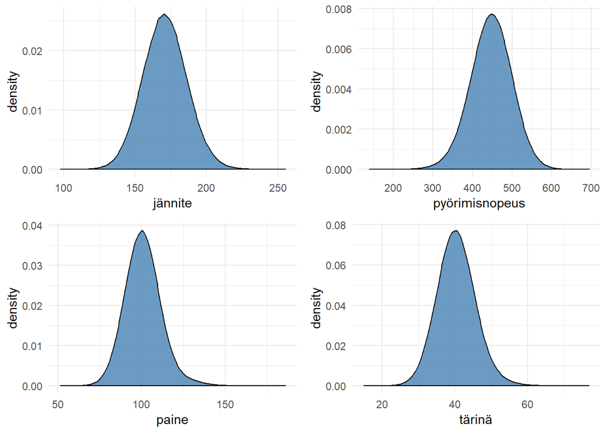

```r
g1 = ggplot(IoT, aes(jännite)) +
  geom_density(col = "black", fill = "steelblue", alpha = 0.8) +
  theme_minimal()
g2 = ggplot(IoT, aes(pyörimisnopeus)) +
  geom_density(col = "black", fill = "steelblue", alpha = 0.8) +
  theme_minimal()
g3 = ggplot(IoT, aes(paine)) +
  geom_density(col = "black", fill = "steelblue", alpha = 0.8) +
  theme_minimal()
g4 = ggplot(IoT, aes(tärinä)) +
  geom_density(col = "black", fill = "steelblue", alpha = 0.8) +
  theme_minimal()
grid.arrange(g1,g2,g3,g4, ncol = 2)
```

Yhden laitteet jännitedatasta eri aikaväleillä nähdään, että mittausarvoissa on jonkin verran satunnaiskohinaa ja selviä piikkejä on havaittavissa. Sama toisuu muillakin suureilla.

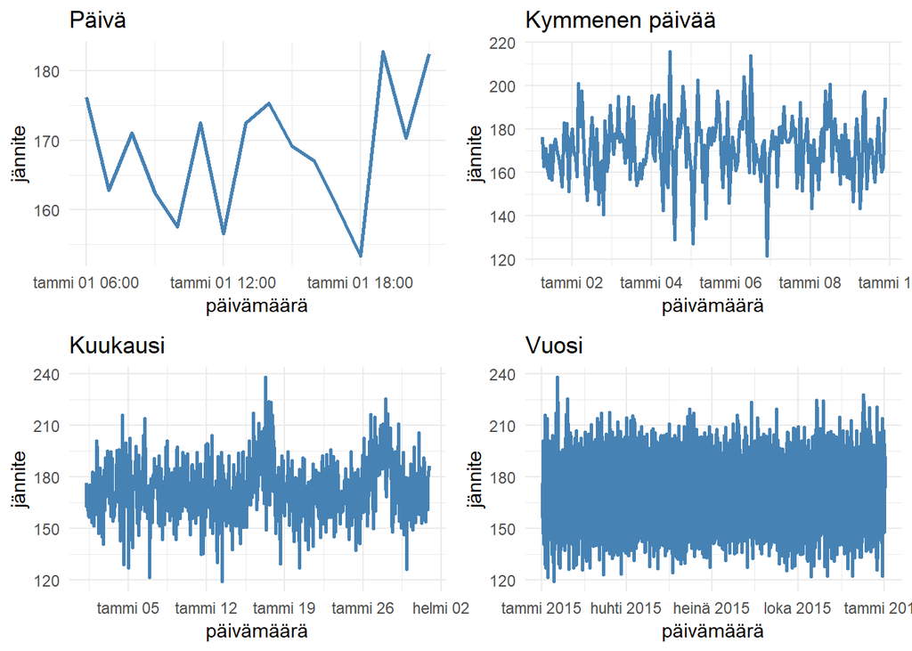

```r
g1 = ggplot(IoT %>% filter(laiteID == 1, aikaleima < as.POSIXct("2015-1-2") ), aes(x = aikaleima, y = jännite)) +
  geom_line(size = 1, col = "steelblue") +
  xlab("päivämäärä") +
  theme_minimal() +
  ggtitle("Päivä")
g2 = ggplot(IoT %>% filter(laiteID == 1, aikaleima < as.POSIXct("2015-1-10") ), aes(x = aikaleima, y = jännite)) +
  geom_line(size = 1, col = "steelblue") +
  xlab("päivämäärä") +
  theme_minimal() +
  ggtitle("Kymmenen päivää")
g3 = ggplot(IoT %>% filter(laiteID == 1, aikaleima < as.POSIXct("2015-2-1") ), aes(x = aikaleima, y = jännite)) +
  geom_line(size = 1, col = "steelblue") +
  xlab("päivämäärä") +
  theme_minimal() +
  ggtitle("Kuukausi")
g4 = ggplot(IoT %>% filter(laiteID == 1), aes(x = aikaleima, y = jännite)) +
  geom_line(size = 1, col = "steelblue") +
  xlab("päivämäärä") +
  theme_minimal() +
  ggtitle("Vuosi")

grid.arrange(g1,g2,g3,g4, ncol = 2)
```

# 3 Selittävien ominaisuuksien rakennus

Jotta laitteiden vikaantumisen mallinnus koneoppimismalleilla onnistuu, data täytyy yhdistellä yhteen tauluun, josta voidaan laskea vikaantumista selittäviä ominaisuuksia, joita koneoppimismalli käyttää ennustamiseen. PdM sovelluksissa on tyypillistä valita jokin aikaikkuna, esim. kolme tuntia, viisi päivää tai kuukausi ja järjestää data yhdeksi aikasarjaksi, joissa data on koottu valittuihin aikaikkunoihin. Aikaikkuna on käytännössä lyhyin aika, jonka malli *näkee eteenpäin* , eli myös lyhyin aika, johon mallin ennustuksia voidaan käyttää. Aikaikkunan valinta riippuu tutkittavien laitteiden keskimääräisestä vikaantumisajasta, vikaantumiskaavasta ja saatavilla olevasta datasta. Tässä demossa aikaikkunaksi valitaan kolme tuntia.

## 3.1 IoT

IoT dataa on mitattu kerran tunnissa, joten sitä täytyy koota, jotta se saadaan kolmen tunnin aikaikkunoihin. Yksi vaihtoehto olisi ottaa vain mittaukset joka kolmannelta tunnilta huomioon, mutta data saadaan paremmin hyödynnettyä laskemalla jokaiselle aikaikkunalle kokoavia tunnuslukuja, kuten liukuvia tunnuslukuja edellisen kolmen tunnin datasta. Datan kokoamisen lisäksi liukuvat tunnusluvut voivat vähentää *satunnaisen kohinan* vaikutusta. Lisäksi tunnuslukuja voidaan laskea myös aikaikkunaa pidemmältä ajanjaksolta, jotta mahdolliset pidempiaikaiset trendit paljastuvat.

Seuraavassa IoT-datan kolmen tunnin liukuvat keskiarvot ensimmäiselle kymmennelle aikaikkunalle

```r
# rollapply paketista zoo
IoT_3h_ka = IoT %>% group_by(laiteID) %>% arrange(laiteID, aikaleima) %>% transmute(aikaleima = aikaleima,
  jännite_3h_ka = rollapply(jännite, width = 3, FUN = mean, by = 3, by.column = T, align = "right", fill = NA),
  pyörimisnopeus_3h_ka = rollapply(pyörimisnopeus, width = 3, FUN = mean, by = 3, by.column = T, align = "right", fill = NA),
  paine_3h_ka = rollapply(paine, width = 3, FUN = mean, by = 3, by.column = T,  align = "right", fill = NA),
  tärinä_3h_ka = rollapply(tärinä, width = 3, FUN = mean, by = 3, by.column = T, align = "right", fill = NA)
) %>% na.omit()

head(IoT_3h_ka, 10) %>% customDfRender()
```

| laiteID | aikaleima | jännite_3h_ka | pyörimisnopeus_3h_ka | paine_3h_ka | tärinä_3h_ka |
| --- | --- | --- | --- | --- | --- |
| 1 | 2015-01-01 08:00:00 | 170.0290 | 449.5338 | 94.59212 | 40.89350 |
| 1 | 2015-01-01 11:00:00 | 164.1926 | 403.9499 | 105.68742 | 34.25589 |
| 1 | 2015-01-01 14:00:00 | 168.1344 | 435.7817 | 107.79371 | 41.23941 |
| 1 | 2015-01-01 17:00:00 | 165.5145 | 430.4728 | 101.70329 | 40.37374 |
| 1 | 2015-01-01 20:00:00 | 168.8093 | 437.1111 | 90.91106 | 41.73854 |
| 1 | 2015-01-01 23:00:00 | 168.7794 | 486.2427 | 90.44647 | 41.79666 |
| 1 | 2015-01-02 02:00:00 | 172.2775 | 477.7386 | 89.10486 | 41.23200 |
| 1 | 2015-01-02 05:00:00 | 180.1338 | 440.6083 | 94.13797 | 41.55154 |
| 1 | 2015-01-02 08:00:00 | 176.3643 | 439.3497 | 101.55321 | 36.10558 |
| 1 | 2015-01-02 11:00:00 | 160.3846 | 424.3853 | 99.59872 | 36.09464 |

Keskiarvon lisäksi voidaan laskea muitakin keskilukuja kuten mediaani, tai liukuvia hajontalukuja, kuten liukuva keskihajonta. Seuraavassa kolmen tunnin liukuvat keskihajonnat.

```r
IoT_3h_sd = IoT %>% group_by(laiteID) %>% arrange(laiteID, aikaleima) %>% transmute(aikaleima = aikaleima,
  jännite_3h_sd = rollapply(jännite, width = 3, FUN = sd, by = 3, by.column = T, align = "right", fill = NA),
  pyörimisnopeus_3h_sd = rollapply(pyörimisnopeus, width = 3, FUN = sd, by = 3, by.column = T, align = "right", fill = NA),
  paine_3h_sd = rollapply(paine, width = 3, FUN = sd, by = 3, by.column = T,  align = "right", fill = NA),
  tärinä_3h_sd = rollapply(tärinä, width = 3, FUN = sd, by = 3, by.column = T, align = "right", fill = NA)
) %>% na.omit()

head(IoT_3h_sd, 10) %>% customDfRender()
```

| laiteID | aikaleima | jännite_3h_sd | pyörimisnopeus_3h_sd | paine_3h_sd | tärinä_3h_sd |
| --- | --- | --- | --- | --- | --- |
| 1 | 2015-01-01 08:00:00 | 6.721032 | 67.84960 | 18.934956 | 5.874970 |
| 1 | 2015-01-01 11:00:00 | 7.596570 | 50.12045 | 8.555032 | 7.662229 |
| 1 | 2015-01-01 14:00:00 | 10.124584 | 55.08473 | 5.909721 | 5.169304 |
| 1 | 2015-01-01 17:00:00 | 4.673269 | 42.04728 | 4.554047 | 2.106108 |
| 1 | 2015-01-01 20:00:00 | 14.752132 | 47.04861 | 4.244159 | 2.207884 |
| 1 | 2015-01-01 23:00:00 | 15.901952 | 36.12955 | 4.310740 | 9.390494 |
| 1 | 2015-01-02 02:00:00 | 6.884615 | 46.85008 | 9.205122 | 3.019906 |
| 1 | 2015-01-02 05:00:00 | 21.322735 | 48.77051 | 2.135684 | 10.037208 |
| 1 | 2015-01-02 08:00:00 | 18.952210 | 51.32964 | 13.789279 | 6.737739 |
| 1 | 2015-01-02 11:00:00 | 13.047080 | 13.70250 | 9.988609 | 1.639962 |

Lasketaan liukuvat keskiarvot ja -hajonnat myös 24 tunnin ajalta pidempiaikaisen efektin tallettamiseksi.

```r
IoT_24h_ka = IoT %>% group_by(laiteID) %>% arrange(laiteID, aikaleima) %>% transmute(aikaleima = aikaleima,
  jännite_24h_ka = rollapply(jännite, width = 24, FUN = mean, by = 3, by.column = T, align = "right", fill = NA),
  pyörimisnopeus_24h_ka = rollapply(pyörimisnopeus, width = 24, FUN = mean, by = 3, by.column = T, align = "right", fill = NA),
  paine_24h_ka = rollapply(paine, width = 24, FUN = mean, by = 3, by.column = T,  align = "right", fill = NA),
  tärinä_24h_ka = rollapply(tärinä, width = 24, FUN = mean, by = 3, by.column = T, align = "right", fill = NA)
) %>% na.omit()

head(IoT_24h_ka, 10) %>% customDfRender()
```

| laiteID | aikaleima | jännite_24h_ka | pyörimisnopeus_24h_ka | paine_24h_ka | tärinä_24h_ka |
| --- | --- | --- | --- | --- | --- |
| 1 | 2015-01-02 05:00:00 | 169.7338 | 445.1799 | 96.79711 | 40.38516 |
| 1 | 2015-01-02 08:00:00 | 170.5257 | 443.9068 | 97.66725 | 39.78667 |
| 1 | 2015-01-02 11:00:00 | 170.0497 | 446.4613 | 96.90616 | 40.01651 |
| 1 | 2015-01-02 14:00:00 | 170.3420 | 447.3553 | 96.22952 | 39.92196 |
| 1 | 2015-01-02 17:00:00 | 170.0606 | 452.1634 | 96.35744 | 39.99047 |
| 1 | 2015-01-02 20:00:00 | 169.3693 | 453.3362 | 98.04201 | 39.53167 |
| 1 | 2015-01-02 23:00:00 | 169.7958 | 446.8327 | 98.45461 | 39.27165 |
| 1 | 2015-01-03 02:00:00 | 170.1623 | 450.2210 | 100.88052 | 38.83814 |
| 1 | 2015-01-03 05:00:00 | 170.3569 | 454.2429 | 100.78767 | 38.47183 |
| 1 | 2015-01-03 08:00:00 | 169.8592 | 462.4668 | 100.40906 | 40.20433 |

```r
IoT_24h_sd = IoT %>% group_by(laiteID) %>% arrange(laiteID, aikaleima) %>% transmute(aikaleima = aikaleima,
  jännite_24h_sd = rollapply(jännite, width = 24, FUN = sd, by = 3, by.column = T, align = "right", fill = NA),
  pyörimisnopeus_24h_sd = rollapply(pyörimisnopeus, width = 24, FUN = sd, by = 3, by.column = T, align = "right", fill = NA),
  paine_24h_sd = rollapply(paine, width = 24, FUN = sd, by = 3, by.column = T,  align = "right", fill = NA),
  tärinä_24h_sd = rollapply(tärinä, width = 24, FUN = sd, by = 3, by.column = T, align = "right", fill = NA)
) %>% na.omit()

head(IoT_24h_sd, 10) %>% customDfRender()
```

| laiteID | aikaleima | jännite_24h_sd | pyörimisnopeus_24h_sd | paine_24h_sd | tärinä_24h_sd |
| --- | --- | --- | --- | --- | --- |
| 1 | 2015-01-02 05:00:00 | 11.23312 | 48.71739 | 10.079880 | 5.853209 |
| 1 | 2015-01-02 08:00:00 | 12.59195 | 46.93028 | 9.406795 | 6.098173 |
| 1 | 2015-01-02 11:00:00 | 13.27734 | 42.83678 | 9.071472 | 5.481724 |
| 1 | 2015-01-02 14:00:00 | 13.81716 | 42.80863 | 8.256794 | 5.862312 |
| 1 | 2015-01-02 17:00:00 | 14.79287 | 42.52529 | 8.669605 | 5.907157 |
| 1 | 2015-01-02 20:00:00 | 15.67479 | 41.68962 | 10.607947 | 6.205887 |
| 1 | 2015-01-02 23:00:00 | 15.74216 | 38.80027 | 11.679314 | 5.579524 |
| 1 | 2015-01-03 02:00:00 | 15.80177 | 40.49000 | 11.323930 | 5.565239 |
| 1 | 2015-01-03 05:00:00 | 15.03377 | 40.85861 | 11.384920 | 5.121860 |
| 1 | 2015-01-03 08:00:00 | 13.95316 | 44.26913 | 10.765817 | 6.023521 |

Yhden laitteen jännitedata ja sen kolmen tunnin liukuva keskiarvo sekä 24 tunnin liukuva keskiarvo eri aikaväleillä näyttävät kuinka liukuvat keskiluvut vähentävät kohinan määrää, mutta säilyttävät tärkeimmät trendit ja piikit pitkällä aikavälillä.

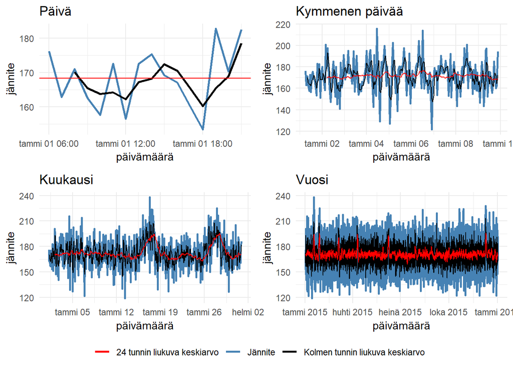

```r
# Tässä data on vielä tunnin välein toisin kuin yllä
firstdaymean = mean(IoT %>% filter(laiteID == 1, aikaleima < as.POSIXct("2015-1-2")) %>% select(jännite) %>% unlist())

g1 = ggplot(IoT %>% filter(laiteID == 1, aikaleima < as.POSIXct("2015-1-2")), aes(x = aikaleima, y = jännite)) +        geom_line(size = 1, aes(linetype = "Jännite"), col = "steelblue") +
  geom_ma(n = 3, aes(linetype = "Kolmen tunnin liukuva keskiarvo"), size = 1, col = "black") +
  geom_hline(aes(yintercept = firstdaymean, linetype = "24 tunnin liukuva keskiarvo"), col = "red") +
  scale_linetype_manual(name = "",values = c(1,1,1),
    guide = guide_legend(override.aes = list(color = c("red","steelblue", "black")))) +
  xlab("päivämäärä") +
  theme_minimal() +
  ggtitle("Päivä")

g2 = ggplot(IoT %>% filter(laiteID == 1, aikaleima < as.POSIXct("2015-1-10") ), aes(x = aikaleima, y = jännite)) +
  geom_line(size = 1, col = "steelblue") +
  xlab("päivämäärä") +
  theme_minimal() +
  ggtitle("Kymmenen päivää") +
  geom_ma(n = 3, col = "black", linetype = "solid") +
  geom_ma(n = 24, col = "red", linetype = "solid")

g3 = ggplot(IoT %>% filter(laiteID == 1, aikaleima < as.POSIXct("2015-2-1") ), aes(x = aikaleima, y = jännite)) +
  geom_line(size = 1, col = "steelblue") +
  xlab("päivämäärä") +
  theme_minimal() +
  ggtitle("Kuukausi") +
  geom_ma(n = 3, col = "black", linetype = "solid") +
  geom_ma(n = 24, col = "red", linetype = "solid")

g4 = ggplot(IoT %>% filter(laiteID == 1), aes(x = aikaleima, y = jännite)) +
  geom_line(size = 1, col = "steelblue") +
  xlab("päivämäärä") +
  theme_minimal() +
  ggtitle("Vuosi") +
  geom_ma(n = 3, col = "black", linetype = "solid") +
  geom_ma(n = 24, col = "red", linetype = "solid")

ggarrange(g1, g2, g3, g4, ncol = 2, nrow = 2, common.legend = T, legend = "bottom")
```

Edellälaskettujen ominaisuuksien lisäksi IoT-datasta voidaan laskea myös esim. maksimi, minimi, vaihteluväli, poikkeavien arvojen määrä jne. Myös aikavälejä voidaan valita useampia. Ylärajana ominaisuuksien määrällä on käytännössä vain laskentateho ja muistin määrä.

Yhdistettynä IoT datasta lasketut ominaisuudet näyttävät tältä

```r
IoTFinal = IoT_3h_ka %>%
  left_join(IoT_24h_ka) %>%
  left_join(IoT_3h_sd) %>%
  left_join(IoT_24h_sd) %>%
  na.omit()
head(IoTFinal, 10) %>% customDfRender(scroll = T)
```

| laiteID | aikaleima | jännite_3h_ka | pyörimisnopeus_3h_ka | paine_3h_ka | tärinä_3h_ka | jännite_24h_ka | pyörimisnopeus_24h_ka | paine_24h_ka | tärinä_24h_ka | jännite_3h_sd | pyörimisnopeus_3h_sd | paine_3h_sd | tärinä_3h_sd | jännite_24h_sd | pyörimisnopeus_24h_sd | paine_24h_sd | tärinä_24h_sd |
| --- | --- | --- | --- | --- | --- | --- | --- | --- | --- | --- | --- | --- | --- | --- | --- | --- | --- |
| 1 | 2015-01-02 05:00:00 | 180.1338 | 440.6083 | 94.13797 | 41.55154 | 169.7338 | 445.1799 | 96.79711 | 40.38516 | 21.322735 | 48.77051 | 2.135684 | 10.037208 | 11.23312 | 48.71739 | 10.079880 | 5.853209 |
| 1 | 2015-01-02 08:00:00 | 176.3643 | 439.3497 | 101.55321 | 36.10558 | 170.5257 | 443.9068 | 97.66725 | 39.78667 | 18.952210 | 51.32964 | 13.789279 | 6.737739 | 12.59195 | 46.93028 | 9.406795 | 6.098173 |
| 1 | 2015-01-02 11:00:00 | 160.3846 | 424.3853 | 99.59872 | 36.09464 | 170.0497 | 446.4613 | 96.90616 | 40.01651 | 13.047080 | 13.70250 | 9.988609 | 1.639962 | 13.27734 | 42.83678 | 9.071472 | 5.481724 |
| 1 | 2015-01-02 14:00:00 | 170.4725 | 442.9340 | 102.38059 | 40.48300 | 170.3420 | 447.3553 | 96.22952 | 39.92196 | 16.642354 | 56.29045 | 3.305739 | 8.854145 | 13.81716 | 42.80863 | 8.256794 | 5.862312 |
| 1 | 2015-01-02 17:00:00 | 163.2638 | 468.9376 | 102.72665 | 40.92180 | 170.0606 | 452.1634 | 96.35744 | 39.99047 | 17.424688 | 38.68038 | 9.105775 | 3.060781 | 14.79287 | 42.52529 | 8.669605 | 5.907157 |
| 1 | 2015-01-02 20:00:00 | 163.2785 | 446.4932 | 104.38758 | 38.06812 | 169.3693 | 453.3362 | 98.04201 | 39.53167 | 21.580492 | 41.38096 | 20.725597 | 6.932127 | 15.67479 | 41.68962 | 10.607947 | 6.205887 |
| 1 | 2015-01-02 23:00:00 | 172.1912 | 434.2147 | 93.74728 | 39.71648 | 169.7958 | 446.8327 | 98.45461 | 39.27165 | 16.369836 | 14.63604 | 18.817326 | 3.426997 | 15.74216 | 38.80027 | 11.679314 | 5.579524 |
| 1 | 2015-01-03 02:00:00 | 175.2100 | 504.8454 | 108.51215 | 37.76393 | 170.1623 | 450.2210 | 100.88052 | 38.83814 | 5.991921 | 16.06270 | 6.382608 | 3.449468 | 15.80177 | 40.49000 | 11.323930 | 5.565239 |
| 1 | 2015-01-03 05:00:00 | 181.6901 | 472.7832 | 93.39516 | 38.62110 | 170.3569 | 454.2429 | 100.78767 | 38.47183 | 11.514450 | 47.88044 | 2.177029 | 7.670520 | 15.03377 | 40.85861 | 11.384920 | 5.121860 |
| 1 | 2015-01-03 08:00:00 | 172.3829 | 505.1413 | 98.52437 | 49.96557 | 169.8592 | 462.4668 | 100.40906 | 40.20433 | 7.065150 | 56.84954 | 5.230039 | 2.687565 | 13.95316 | 44.26913 | 10.765817 | 6.023521 |

## 3.2 Virheet

Virheistä laskettavia ominaisuuksia ovat esim. eri virhetyyppien määrät valitulta aikaväliltä. Valitaan aikaväliksi 24 tuntia ja lasketaan se valittuihin kolmen tunnin aikaikkunoihin.

```r
# Dummyt
virhecount <- Virheet %>% select(aikaleima, laiteID, virheID) %>% mutate(
  error1 = as.integer(virheID == "error1"),
  error2 = as.integer(virheID == "error2"),
  error3 = as.integer(virheID == "error3"),
  error4 = as.integer(virheID == "error4"),
  error5 = as.integer(virheID == "error5")
)
# Summataan duplikaattivirheet samalta tunnilta
virhecount <- virhecount %>% group_by(laiteID, aikaleima) %>% summarise(
  error1kpl = sum(error1),
  error2kpl = sum(error2),
  error3kpl = sum(error3),
  error4kpl = sum(error4),
  error5kpl = sum(error5)
) %>% ungroup()

virhefeat = IoT %>% select(aikaleima, laiteID) %>% left_join(virhecount) %>% ungroup()
virhefeat[is.na(virhefeat)] = 0

## Summataan 24h

virhefeat <- virhefeat %>% arrange(laiteID, aikaleima) %>% group_by(laiteID) %>% mutate(
  error1kpl = rollapply(error1kpl, width = 24, FUN = sum, align = "right", fill = NA, by = 3),
  error2kpl = rollapply(error2kpl, width = 24, FUN = sum, align = "right", fill = NA, by = 3),
  error3kpl = rollapply(error3kpl, width = 24, FUN = sum, align = "right", fill = NA, by = 3),
  error4kpl = rollapply(error4kpl, width = 24, FUN = sum, align = "right", fill = NA, by = 3),
  error5kpl = rollapply(error5kpl, width = 24, FUN = sum, align = "right", fill = NA, by = 3)
) %>% select(aikaleima, laiteID, error1kpl, error2kpl, error3kpl, error4kpl, error5kpl) %>% filter(!is.na(error1kpl)) %>% ungroup()

virhefeat[5:15,] %>% customDfRender()
```

| aikaleima | laiteID | error1kpl | error2kpl | error3kpl | error4kpl | error5kpl |
| --- | --- | --- | --- | --- | --- | --- |
| 2015-01-02 17:00:00 | 1 | 0 | 0 | 0 | 0 | 0 |
| 2015-01-02 20:00:00 | 1 | 0 | 0 | 0 | 0 | 0 |
| 2015-01-02 23:00:00 | 1 | 0 | 0 | 0 | 0 | 0 |
| 2015-01-03 02:00:00 | 1 | 0 | 0 | 0 | 0 | 0 |
| 2015-01-03 05:00:00 | 1 | 0 | 0 | 0 | 0 | 0 |
| 2015-01-03 08:00:00 | 1 | 1 | 0 | 0 | 0 | 0 |
| 2015-01-03 11:00:00 | 1 | 1 | 0 | 0 | 0 | 0 |
| 2015-01-03 14:00:00 | 1 | 1 | 0 | 0 | 0 | 0 |
| 2015-01-03 17:00:00 | 1 | 1 | 0 | 0 | 0 | 0 |
| 2015-01-03 20:00:00 | 1 | 1 | 0 | 1 | 0 | 0 |
| 2015-01-03 23:00:00 | 1 | 1 | 0 | 1 | 0 | 0 |

Tässä siis laiteID 1 sai virheilmoituksen error1 päivämääränä 2015-01-03 jossain aikavälillä 05:00 - 08:00.

## 3.3 Huollot

Huolloista laskettavista ominaisuuksista olennaisin on *aikaa viime huollosta* jokaiselle kolmen tunnin aikaikkunalle komponenteittain.

```r
# Dummyt
comprep <- Huollot %>% select(aikaleima, laiteID, komponentti) %>% mutate(
  comp1 = as.integer(komponentti == "comp1"),
  comp2 = as.integer(komponentti == "comp2"),
  comp3 = as.integer(komponentti == "comp3"),
  comp4 = as.integer(komponentti == "comp4")
) %>% select(-komponentti)

## yhdistetään seuraavaan aikaleimaan data.table rolling joinilla

comprep <- as.data.table(comprep)
setkey(comprep, laiteID, aikaleima)

comp1rep <- comprep[comp1 == 1, .(laiteID, aikaleima, lastrepcomp1 = aikaleima)]
comp2rep <- comprep[comp2 == 1, .(laiteID, aikaleima, lastrepcomp2 = aikaleima)]
comp3rep <- comprep[comp3 == 1, .(laiteID, aikaleima, lastrepcomp3 = aikaleima)]
comp4rep <- comprep[comp4 == 1, .(laiteID, aikaleima, lastrepcomp4 = aikaleima)]

compdate <- as.data.table(IoTFinal[,c(1:2)])
setkey(compdate, laiteID, aikaleima)
comp1feat <- comp1rep[compdate[,.(laiteID, aikaleima)],roll = TRUE]
comp1feat$huollostacomp1 <- as.numeric(difftime(comp1feat$aikaleima, comp1feat$lastrepcomp1, units = "days"))
comp2feat <- comp2rep[compdate[,.(laiteID, aikaleima)], roll = TRUE]
comp2feat$huollostacomp2 <- as.numeric(difftime(comp2feat$aikaleima, comp2feat$lastrepcomp2, units = "days"))
comp3feat <- comp3rep[compdate[,.(laiteID, aikaleima)], roll = TRUE]
comp3feat$huollostacomp3 <- as.numeric(difftime(comp3feat$aikaleima, comp3feat$lastrepcomp3, units="days"))
comp4feat <- comp4rep[compdate[,.(laiteID, aikaleima)], roll = TRUE]
comp4feat$huollostacomp4 <- as.numeric(difftime(comp4feat$aikaleima, comp4feat$lastrepcomp4, units = "days"))

compfeat <-data.frame(compdate, comp1feat[,.(huollostacomp1)], comp2feat[,.(huollostacomp2)], comp3feat[,.(huollostacomp3)],comp4feat[,.(huollostacomp4)])

head(compfeat, 10) %>% customDfRender()
```

| laiteID | aikaleima | huollostacomp1 | huollostacomp2 | huollostacomp3 | huollostacomp4 |
| --- | --- | --- | --- | --- | --- |
| 1 | 2015-01-02 05:00:00 | 19.95833 | 214.9583 | 154.9583 | 169.9583 |
| 1 | 2015-01-02 08:00:00 | 20.08333 | 215.0833 | 155.0833 | 170.0833 |
| 1 | 2015-01-02 11:00:00 | 20.20833 | 215.2083 | 155.2083 | 170.2083 |
| 1 | 2015-01-02 14:00:00 | 20.33333 | 215.3333 | 155.3333 | 170.3333 |
| 1 | 2015-01-02 17:00:00 | 20.45833 | 215.4583 | 155.4583 | 170.4583 |
| 1 | 2015-01-02 20:00:00 | 20.58333 | 215.5833 | 155.5833 | 170.5833 |
| 1 | 2015-01-02 23:00:00 | 20.70833 | 215.7083 | 155.7083 | 170.7083 |
| 1 | 2015-01-03 02:00:00 | 20.83333 | 215.8333 | 155.8333 | 170.8333 |
| 1 | 2015-01-03 05:00:00 | 20.95833 | 215.9583 | 155.9583 | 170.9583 |
| 1 | 2015-01-03 08:00:00 | 21.08333 | 216.0833 | 156.0833 | 171.0833 |

Lopulliset temporaaliset ominaisuudet ovat yhdistettynä tässä

```r
IoTFinal %>%
  left_join(virhefeat) %>%
  left_join(compfeat) %>%
  head(10) %>%
  customDfRender(scroll = T)
```

| laiteID | aikaleima | jännite_3h_ka | pyörimisnopeus_3h_ka | paine_3h_ka | tärinä_3h_ka | jännite_24h_ka | pyörimisnopeus_24h_ka | paine_24h_ka | tärinä_24h_ka | jännite_3h_sd | pyörimisnopeus_3h_sd | paine_3h_sd | tärinä_3h_sd | jännite_24h_sd | pyörimisnopeus_24h_sd | paine_24h_sd | tärinä_24h_sd | error1kpl | error2kpl | error3kpl | error4kpl | error5kpl | huollostacomp1 | huollostacomp2 | huollostacomp3 | huollostacomp4 |
| --- | --- | --- | --- | --- | --- | --- | --- | --- | --- | --- | --- | --- | --- | --- | --- | --- | --- | --- | --- | --- | --- | --- | --- | --- | --- | --- |
| 1 | 2015-01-02 05:00:00 | 180.1338 | 440.6083 | 94.13797 | 41.55154 | 169.7338 | 445.1799 | 96.79711 | 40.38516 | 21.322735 | 48.77051 | 2.135684 | 10.037208 | 11.23312 | 48.71739 | 10.079880 | 5.853209 | 0 | 0 | 0 | 0 | 0 | 19.95833 | 214.9583 | 154.9583 | 169.9583 |
| 1 | 2015-01-02 08:00:00 | 176.3643 | 439.3497 | 101.55321 | 36.10558 | 170.5257 | 443.9068 | 97.66725 | 39.78667 | 18.952210 | 51.32964 | 13.789279 | 6.737739 | 12.59195 | 46.93028 | 9.406795 | 6.098173 | 0 | 0 | 0 | 0 | 0 | 20.08333 | 215.0833 | 155.0833 | 170.0833 |
| 1 | 2015-01-02 11:00:00 | 160.3846 | 424.3853 | 99.59872 | 36.09464 | 170.0497 | 446.4613 | 96.90616 | 40.01651 | 13.047080 | 13.70250 | 9.988609 | 1.639962 | 13.27734 | 42.83678 | 9.071472 | 5.481724 | 0 | 0 | 0 | 0 | 0 | 20.20833 | 215.2083 | 155.2083 | 170.2083 |
| 1 | 2015-01-02 14:00:00 | 170.4725 | 442.9340 | 102.38059 | 40.48300 | 170.3420 | 447.3553 | 96.22952 | 39.92196 | 16.642354 | 56.29045 | 3.305739 | 8.854145 | 13.81716 | 42.80863 | 8.256794 | 5.862312 | 0 | 0 | 0 | 0 | 0 | 20.33333 | 215.3333 | 155.3333 | 170.3333 |
| 1 | 2015-01-02 17:00:00 | 163.2638 | 468.9376 | 102.72665 | 40.92180 | 170.0606 | 452.1634 | 96.35744 | 39.99047 | 17.424688 | 38.68038 | 9.105775 | 3.060781 | 14.79287 | 42.52529 | 8.669605 | 5.907157 | 0 | 0 | 0 | 0 | 0 | 20.45833 | 215.4583 | 155.4583 | 170.4583 |
| 1 | 2015-01-02 20:00:00 | 163.2785 | 446.4932 | 104.38758 | 38.06812 | 169.3693 | 453.3362 | 98.04201 | 39.53167 | 21.580492 | 41.38096 | 20.725597 | 6.932127 | 15.67479 | 41.68962 | 10.607947 | 6.205887 | 0 | 0 | 0 | 0 | 0 | 20.58333 | 215.5833 | 155.5833 | 170.5833 |
| 1 | 2015-01-02 23:00:00 | 172.1912 | 434.2147 | 93.74728 | 39.71648 | 169.7958 | 446.8327 | 98.45461 | 39.27165 | 16.369836 | 14.63604 | 18.817326 | 3.426997 | 15.74216 | 38.80027 | 11.679314 | 5.579524 | 0 | 0 | 0 | 0 | 0 | 20.70833 | 215.7083 | 155.7083 | 170.7083 |
| 1 | 2015-01-03 02:00:00 | 175.2100 | 504.8454 | 108.51215 | 37.76393 | 170.1623 | 450.2210 | 100.88052 | 38.83814 | 5.991921 | 16.06270 | 6.382608 | 3.449468 | 15.80177 | 40.49000 | 11.323930 | 5.565239 | 0 | 0 | 0 | 0 | 0 | 20.83333 | 215.8333 | 155.8333 | 170.8333 |
| 1 | 2015-01-03 05:00:00 | 181.6901 | 472.7832 | 93.39516 | 38.62110 | 170.3569 | 454.2429 | 100.78767 | 38.47183 | 11.514450 | 47.88044 | 2.177029 | 7.670520 | 15.03377 | 40.85861 | 11.384920 | 5.121860 | 0 | 0 | 0 | 0 | 0 | 20.95833 | 215.9583 | 155.9583 | 170.9583 |
| 1 | 2015-01-03 08:00:00 | 172.3829 | 505.1413 | 98.52437 | 49.96557 | 169.8592 | 462.4668 | 100.40906 | 40.20433 | 7.065150 | 56.84954 | 5.230039 | 2.687565 | 13.95316 | 44.26913 | 10.765817 | 6.023521 | 1 | 0 | 0 | 0 | 0 | 21.08333 | 216.0833 | 156.0833 | 171.0833 |

Niihin voidaan yhdistää vielä laitteiden staattinen metadata ja saadaan lopulliset ominaisuudet. Jos olisi olemassa dataa laitteiden käytöstä, niin voitaisiin laskea esim. käyttö- tai tuotantomääriä valittujen aikavälien aikana. Kaiken kaikkiaan ominaisuuksien luomisessa vain mielikuvitus on rajana.

```r
final_features = IoTFinal %>%
  left_join(virhefeat) %>%
  left_join(compfeat) %>%
  left_join(Laitteet)
head(final_features, 10) %>% customDfRender(scroll = T)
```

| laiteID | aikaleima | jännite_3h_ka | pyörimisnopeus_3h_ka | paine_3h_ka | tärinä_3h_ka | jännite_24h_ka | pyörimisnopeus_24h_ka | paine_24h_ka | tärinä_24h_ka | jännite_3h_sd | pyörimisnopeus_3h_sd | paine_3h_sd | tärinä_3h_sd | jännite_24h_sd | pyörimisnopeus_24h_sd | paine_24h_sd | tärinä_24h_sd | error1kpl | error2kpl | error3kpl | error4kpl | error5kpl | huollostacomp1 | huollostacomp2 | huollostacomp3 | huollostacomp4 | malli | ikä |
| --- | --- | --- | --- | --- | --- | --- | --- | --- | --- | --- | --- | --- | --- | --- | --- | --- | --- | --- | --- | --- | --- | --- | --- | --- | --- | --- | --- | --- |
| 1 | 2015-01-02 05:00:00 | 180.1338 | 440.6083 | 94.13797 | 41.55154 | 169.7338 | 445.1799 | 96.79711 | 40.38516 | 21.322735 | 48.77051 | 2.135684 | 10.037208 | 11.23312 | 48.71739 | 10.079880 | 5.853209 | 0 | 0 | 0 | 0 | 0 | 19.95833 | 214.9583 | 154.9583 | 169.9583 | model3 | 18 |
| 1 | 2015-01-02 08:00:00 | 176.3643 | 439.3497 | 101.55321 | 36.10558 | 170.5257 | 443.9068 | 97.66725 | 39.78667 | 18.952210 | 51.32964 | 13.789279 | 6.737739 | 12.59195 | 46.93028 | 9.406795 | 6.098173 | 0 | 0 | 0 | 0 | 0 | 20.08333 | 215.0833 | 155.0833 | 170.0833 | model3 | 18 |
| 1 | 2015-01-02 11:00:00 | 160.3846 | 424.3853 | 99.59872 | 36.09464 | 170.0497 | 446.4613 | 96.90616 | 40.01651 | 13.047080 | 13.70250 | 9.988609 | 1.639962 | 13.27734 | 42.83678 | 9.071472 | 5.481724 | 0 | 0 | 0 | 0 | 0 | 20.20833 | 215.2083 | 155.2083 | 170.2083 | model3 | 18 |
| 1 | 2015-01-02 14:00:00 | 170.4725 | 442.9340 | 102.38059 | 40.48300 | 170.3420 | 447.3553 | 96.22952 | 39.92196 | 16.642354 | 56.29045 | 3.305739 | 8.854145 | 13.81716 | 42.80863 | 8.256794 | 5.862312 | 0 | 0 | 0 | 0 | 0 | 20.33333 | 215.3333 | 155.3333 | 170.3333 | model3 | 18 |
| 1 | 2015-01-02 17:00:00 | 163.2638 | 468.9376 | 102.72665 | 40.92180 | 170.0606 | 452.1634 | 96.35744 | 39.99047 | 17.424688 | 38.68038 | 9.105775 | 3.060781 | 14.79287 | 42.52529 | 8.669605 | 5.907157 | 0 | 0 | 0 | 0 | 0 | 20.45833 | 215.4583 | 155.4583 | 170.4583 | model3 | 18 |
| 1 | 2015-01-02 20:00:00 | 163.2785 | 446.4932 | 104.38758 | 38.06812 | 169.3693 | 453.3362 | 98.04201 | 39.53167 | 21.580492 | 41.38096 | 20.725597 | 6.932127 | 15.67479 | 41.68962 | 10.607947 | 6.205887 | 0 | 0 | 0 | 0 | 0 | 20.58333 | 215.5833 | 155.5833 | 170.5833 | model3 | 18 |
| 1 | 2015-01-02 23:00:00 | 172.1912 | 434.2147 | 93.74728 | 39.71648 | 169.7958 | 446.8327 | 98.45461 | 39.27165 | 16.369836 | 14.63604 | 18.817326 | 3.426997 | 15.74216 | 38.80027 | 11.679314 | 5.579524 | 0 | 0 | 0 | 0 | 0 | 20.70833 | 215.7083 | 155.7083 | 170.7083 | model3 | 18 |
| 1 | 2015-01-03 02:00:00 | 175.2100 | 504.8454 | 108.51215 | 37.76393 | 170.1623 | 450.2210 | 100.88052 | 38.83814 | 5.991921 | 16.06270 | 6.382608 | 3.449468 | 15.80177 | 40.49000 | 11.323930 | 5.565239 | 0 | 0 | 0 | 0 | 0 | 20.83333 | 215.8333 | 155.8333 | 170.8333 | model3 | 18 |
| 1 | 2015-01-03 05:00:00 | 181.6901 | 472.7832 | 93.39516 | 38.62110 | 170.3569 | 454.2429 | 100.78767 | 38.47183 | 11.514450 | 47.88044 | 2.177029 | 7.670520 | 15.03377 | 40.85861 | 11.384920 | 5.121860 | 0 | 0 | 0 | 0 | 0 | 20.95833 | 215.9583 | 155.9583 | 170.9583 | model3 | 18 |
| 1 | 2015-01-03 08:00:00 | 172.3829 | 505.1413 | 98.52437 | 49.96557 | 169.8592 | 462.4668 | 100.40906 | 40.20433 | 7.065150 | 56.84954 | 5.230039 | 2.687565 | 13.95316 | 44.26913 | 10.765817 | 6.023521 | 1 | 0 | 0 | 0 | 0 | 21.08333 | 216.0833 | 156.0833 | 171.0833 | model3 | 18 |

# 4 Ennustettavan muuttujan luominen

Jotta koneoppimismalli voidaan ottaa käyttöön edellä olevien ominaisuuksien pohjalta, tarvitaan selitettävä muuttuja. PdM:ssä kiinnostuksen alaisena on laitteen vikaantuminen, joten malli tarvitsee vikaantumiseen liittyvän selitettävän muuttujan. Käytännössä muuttujan luomiseen on kaksi paradigmaa, jotka johtavat kahteen erilaiseen mallinustapaan.

1. Luokitellaan aikaikkunat, jotka osuvat valittuun aikaväliin ennen vikaantumista *Vikaantumassa oleviksi* ja kaikki muut *Normaaliksi*. Valittua aikaväliä kutsutaan ennusteikkunaksi. Ennustettava muuttuja on siis binaarinen kategorinen muuttuja, jonka tasot ovat *normaali* ja *vikaantuva*. Näin luodun ennustettavan muuttujan kanssa tehty malli antaa ennusteensa muodossa “Laitteen todennäköisyys vikaantua ennusteikkunan aikana on **x** prosenttia”. Jos komponenttikohtaista vikaantumisdataa on saatavilla - kuten demossamme - luokittelu tehdään *Vikaantumassa oleviksi komponentin* **y** *takia* ja *Normaaliksi*. Tällöin ennuste on muotoa “Laitteen todennäköisyys vikaantua ennusteikkunan aikana komponentin **y** takia on **x** prosenttia”. Selitettävä muuttuja on tällöin moniluokkainen kategorinen muuttuja, jonka tasot ovat *Normaali*, *Vikaantumassa komponentin* **y1** *takia*, *Vikaantumassa komponentin* **y2** *takia* jne.
2. Lasketaan jokaiselle aikaikkunalle arvo *päivää seuraavaan vikaan*, eli *RUL* ja käytetään sitä ennustettavana muuttujana. Ennustettava muuttuja on tällöin numeerinen. Tällöin ennusteet ovat muotoa “Laitteen todennäkösimpään hajoamispäivään on **x** päivää” tai vastaavasti “Laitteella on jäljellä käyttöaikaa **x** päivää”. Myös RUL voidaan laskea komponenteittain, jolloin ennusteet ovat muotoa "Komponentin **y** todennäköisimpään hajoamispäivään on **x** päivää. Tällöin jokaisen laitteen jokaista komponenttiä kohdellaan ikään kuin omana laitteenaan ja on tehtävä yhtä monta numeerista selitettävää muuttujaa kuin ennustettavia komponentteja on per laite.

Toinen lähestymistapa on varsinkin yhden komponentin tilanteessa mallinnusteknisesti ja tulosten tulkittavuuden kannalta yksinkertaisempi, mutta siinä on yksi heikkous; mallin opettamiseen voidaan käyttää vain aikaikkunoita, joille RUL on laskettavissa. Toisin sanoen jokaisella laitteelle voidaan käyttää dataa vain sen viimeisimpään vikaan asti. Toinen lähestymistapa toimii parhaiten tilanteissa, jolloin laitteen kuluminen on tasaista ja ennen vikaantumista on löydettävissä laitteen kulumista kuvaava trendi selittävistä muuttujista. Jos selkeää trendiä ei ole ja selittävien muuttujien arvoissa tapahtuu eroja vasta lyhyellä aikavälillä ennen vikaantumista, ensimmäinen lähestymistapa on toimivampi. Komponentittainen lähestymistapa on järkevä, jos eri komponenttien vioilla on huomattavissa eroja selittävissä muuttujissa.

Tehdään kohdan 1 mukainen selitettävä muuttuja *Vika* komponentittain

```r
labeled <- left_join(final_features, Viat, by = c("laiteID")) %>%
  mutate(datediff = difftime(aikaleima.y, aikaleima.x, units = "hours")) %>%
  filter(datediff <= 24, datediff >= 0)

final_features <- left_join(
  final_features,
  labeled %>% select(aikaleima.x, laiteID, komponentti),
  by = c("aikaleima" = "aikaleima.x", "laiteID")) %>%
  arrange(laiteID, aikaleima)

levels(final_features$komponentti) <- c(levels(final_features$komponentti), "normaali")
final_features$komponentti[is.na(final_features$komponentti)]<-"normaali"
final_features = final_features %>% rename(Vika = komponentti) %>% arrange(laiteID, aikaleima)

final_features %>%
  select(laiteID, aikaleima,  Vika) %>%
  ungroup() %>%
  filter(between(row_number(), 10, 20)) %>%
  customDfRender()
```

| laiteID | aikaleima | Vika |
| --- | --- | --- |
| 1 | 2015-01-03 08:00:00 | normaali |
| 1 | 2015-01-03 11:00:00 | normaali |
| 1 | 2015-01-03 14:00:00 | normaali |
| 1 | 2015-01-03 17:00:00 | normaali |
| 1 | 2015-01-03 20:00:00 | normaali |
| 1 | 2015-01-03 23:00:00 | normaali |
| 1 | 2015-01-04 02:00:00 | normaali |
| 1 | 2015-01-04 05:00:00 | normaali |
| 1 | 2015-01-04 08:00:00 | comp4 |
| 1 | 2015-01-04 11:00:00 | comp4 |
| 1 | 2015-01-04 14:00:00 | comp4 |

Tehdään myös kohdan kaksi mukainen selitettävä muuttuja *RUL* komponentittain.

```r
## Lasketaan myös minimi komponenttien viime huollosta
final_features = final_features %>% mutate(viimeHuollosta = pmin(huollostacomp1, huollostacomp2, huollostacomp3, huollostacomp4))
## data.table rolling join jälleen
final_features_join = final_features %>% select(aikaleima, laiteID) %>% mutate(joindatetime = aikaleima) %>% as.data.table()
failures_join_comp1 = Viat %>% filter(komponentti == "comp1") %>% mutate(joindatetime = aikaleima) %>% as.data.table()
failures_join_comp2 = Viat %>% filter(komponentti == "comp2") %>% mutate(joindatetime = aikaleima) %>% as.data.table()
failures_join_comp3 = Viat %>% filter(komponentti == "comp3") %>% mutate(joindatetime = aikaleima) %>% as.data.table()
failures_join_comp4 = Viat %>% filter(komponentti == "comp4") %>% mutate(joindatetime = aikaleima) %>% as.data.table()


setkey(failures_join_comp1, laiteID, joindatetime)
setkey(failures_join_comp2, laiteID, joindatetime)
setkey(failures_join_comp3, laiteID, joindatetime)
setkey(failures_join_comp4, laiteID, joindatetime)

setkey(final_features_join, laiteID, joindatetime)

nextFail_comp1 = failures_join_comp1[final_features_join, roll = -Inf] %>% mutate(RUL_comp1 = as.numeric(difftime(aikaleima, joindatetime, units = "days")))
nextFail_comp2 = failures_join_comp2[final_features_join, roll = -Inf] %>% mutate(RUL_comp2 = as.numeric(difftime(aikaleima, joindatetime, units = "days")))
nextFail_comp3 = failures_join_comp3[final_features_join, roll = -Inf] %>% mutate(RUL_comp3 = as.numeric(difftime(aikaleima, joindatetime, units = "days")))
nextFail_comp4 = failures_join_comp4[final_features_join, roll = -Inf] %>% mutate(RUL_comp4 = as.numeric(difftime(aikaleima, joindatetime, units = "days")))



final_features = final_features %>% ungroup() %>%  mutate(RUL_comp1 = nextFail_comp1$RUL_comp1, RUL_comp2 = nextFail_comp2$RUL_comp2, RUL_comp3 = nextFail_comp3$RUL_comp3, RUL_comp4 = nextFail_comp4$RUL_comp4)
head(final_features %>% select(laiteID, aikaleima, RUL_comp1, RUL_comp2, RUL_comp3, RUL_comp4), 10) %>% customDfRender()
```

| laiteID | aikaleima | RUL_comp1 | RUL_comp2 | RUL_comp3 | RUL_comp4 |
| --- | --- | --- | --- | --- | --- |
| 1 | 2015-01-02 05:00:00 | 63.04167 | 108.0417 | NA | 3.041667 |
| 1 | 2015-01-02 08:00:00 | 62.91667 | 107.9167 | NA | 2.916667 |
| 1 | 2015-01-02 11:00:00 | 62.79167 | 107.7917 | NA | 2.791667 |
| 1 | 2015-01-02 14:00:00 | 62.66667 | 107.6667 | NA | 2.666667 |
| 1 | 2015-01-02 17:00:00 | 62.54167 | 107.5417 | NA | 2.541667 |
| 1 | 2015-01-02 20:00:00 | 62.41667 | 107.4167 | NA | 2.416667 |
| 1 | 2015-01-02 23:00:00 | 62.29167 | 107.2917 | NA | 2.291667 |
| 1 | 2015-01-03 02:00:00 | 62.16667 | 107.1667 | NA | 2.166667 |
| 1 | 2015-01-03 05:00:00 | 62.04167 | 107.0417 | NA | 2.041667 |
| 1 | 2015-01-03 08:00:00 | 61.91667 | 106.9167 | NA | 1.916667 |

RUL saa puuttuvan arvon NA, jos kyseinen komponentti ei ole vikaantunut kyseisen aikaikkunan jälkeen kyseisellä laitteella. Tässä laiteID:n 1 komponentti kolme ei ole vikaantunut tarksteluaikana, joten arvo on NA jokaiselle aikaikkunalle.

Tarkastellaan seuraavaksi graafisesti kumpi mallinnuslähestymistavoista on järkevämpi. Allaolevassa kuvassa on aikasarja jännitteen ja tärinän liukavasta keskiarvosta, jossa virheet on merkattu pystyviivoin.

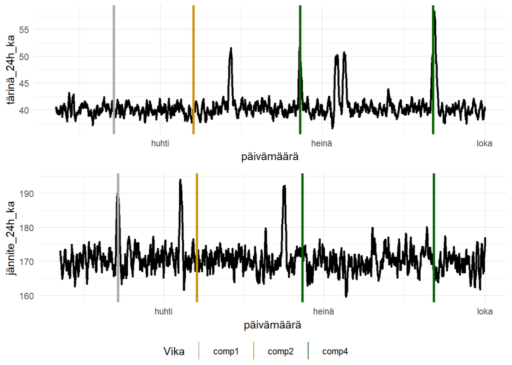

```r
g1 = ggplot(
    final_features %>% filter(laiteID == 1, aikaleima < "2015-10-1", aikaleima > "2015-2-1"),
    aes(x = aikaleima, y = tärinä_24h_ka)) +
  geom_line(size = 1) +
  geom_vline(
    data = final_features %>% filter(laiteID == 1 & Vika != "normaali") %>% select(aikaleima, Vika),
    aes(xintercept = aikaleima, colour = Vika)) +
  theme_minimal() +
  xlab("päivämäärä") +
  scale_color_manual(values = custom.col[3:5])

g2 = ggplot(
    final_features %>% filter(laiteID == 1, aikaleima < "2015-10-1", aikaleima > "2015-2-1"),
    aes(x = aikaleima, y = jännite_24h_ka)) +
  geom_line(size = 1) +
  geom_vline(
    data = final_features %>% filter(laiteID == 1 & Vika != "normaali") %>% select(aikaleima, Vika),
    aes(xintercept = aikaleima, colour = Vika)) +
  theme_minimal() +
  xlab("päivämäärä") +
  scale_color_manual(values = custom.col[3:5])
ggarrange(g1,g2, nrow = 2, common.legend = T, legend = "bottom")
```

Nähdään, että selvää trendiä ennen vikoja ei ole, vaan muutokset arvoissa seuraavat äkillisiä piikkejä. Alla on tärinän ja jännitteen 24 tunnin liukuvien keskiarvojen tiheyfunktiot luokiteltuna muuttujan *RUL* luokkiin.

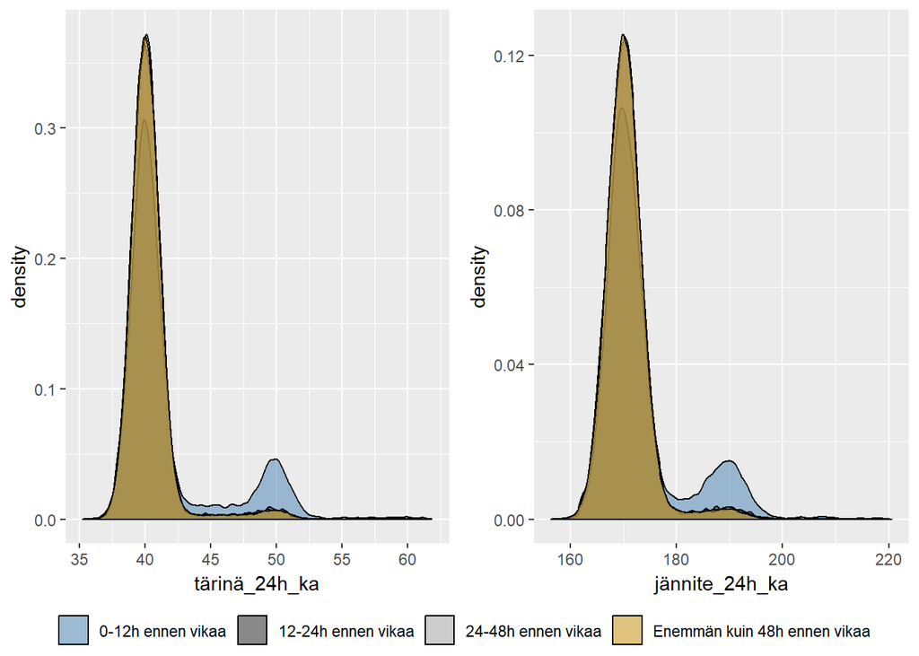

```r
Rg = final_features$RUL_comp4
Rgs = character()
Rgs[Rg < 12] = "0-12h ennen vikaa"
Rgs[Rg >= 12 & Rg < 24] = "12-24h ennen vikaa"
Rgs[Rg >= 24 & Rg < 48] = "24-48h ennen vikaa"
Rgs[Rg >= 48] = "Enemmän kuin 48h ennen vikaa"
Rgs[is.na(Rg)] = "Enemmän kuin 48h ennen vikaa"
Rgs1 = Rgs
g1 = ggplot(final_features %>% mutate(RULgroups = factor(Rgs)), aes(x = tärinä_24h_ka, fill = RULgroups)) +
  geom_density(alpha = 0.5) +
  scale_fill_manual(name = "", values = custom.col)


Rg = final_features$RUL_comp1
Rgs = character()
Rgs[Rg < 12] = "0-12h ennen vikaa"
Rgs[Rg >= 12 & Rg < 24] = "12-24h ennen vikaa"
Rgs[Rg >= 24 & Rg < 48] = "24-48h ennen vikaa"
Rgs[Rg >= 48] = "Enemmän kuin 48h ennen vikaa"
Rgs[is.na(Rg)] = "Enemmän kuin 48h ennen vikaa"
g2 = ggplot(final_features %>% mutate(RULgroups = factor(Rgs)), aes(x = jännite_24h_ka, fill = RULgroups)) +
  geom_density(alpha = 0.5) +
  scale_fill_manual(name = "", values = custom.col)

ggarrange(g1,g2,ncol = 2, common.legend = T, legend = "bottom")
```

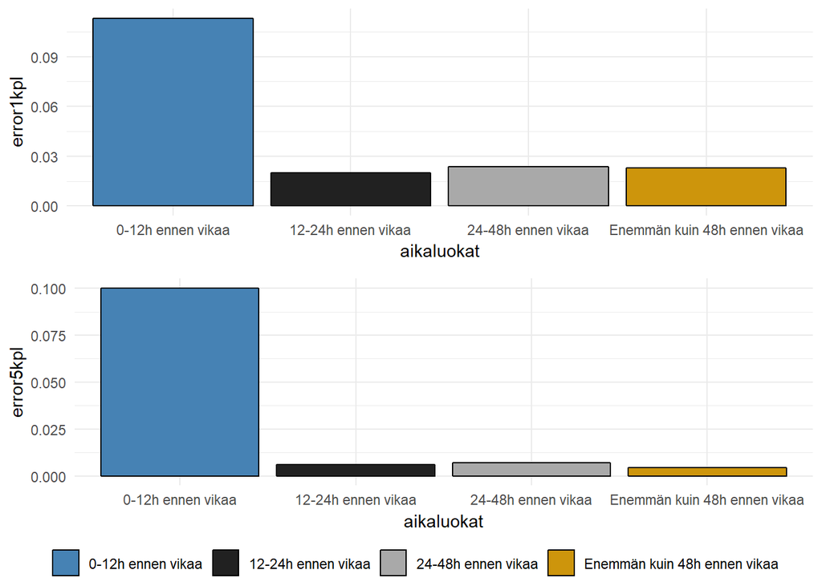

```r
g1 = ggplot(final_features %>% mutate(Rg = Rgs), aes(x = Rg, y = error1kpl, fill = Rg)) +
  geom_bar(stat = "summary", fun.y = mean, col = "black") +
  theme_minimal() +
  scale_fill_manual(name = "", values = custom.col) +
  xlab("aikaluokat")
g2 = ggplot(final_features %>% mutate(Rg = Rgs1), aes(x = Rg, y = error5kpl, fill = Rg)) +
  geom_bar(stat = "summary", fun.y = mean, col = "black") +
  theme_minimal() +
  scale_fill_manual(name = "", values = custom.col) +
  xlab("aikaluokat")
ggarrange(g1,g2,nrow = 2, common.legend = T, legend = "bottom")
```

Alla IoT-datan 24 tunnin liukuvien keskiarvojen jakaumat selitettävän muuttujan *Vika* luokissa.

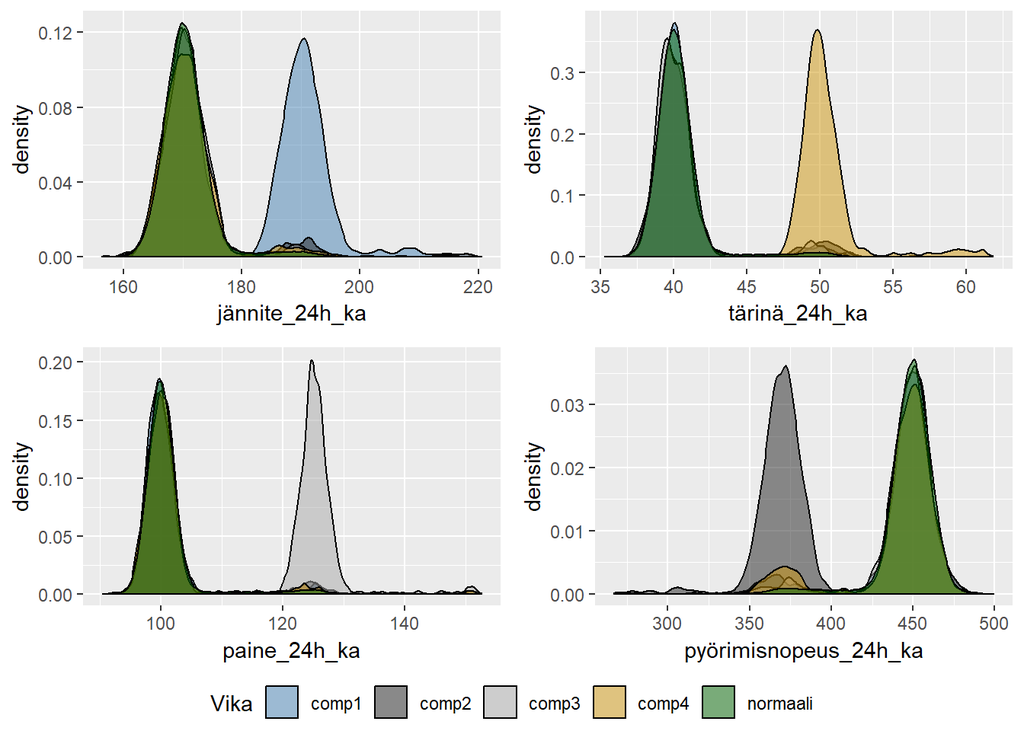

```r
g1 = ggplot(final_features, aes(jännite_24h_ka, fill = Vika)) +
  geom_density(alpha = 0.5) +
  scale_fill_manual(values = custom.col)
g2 = ggplot(final_features, aes(tärinä_24h_ka, fill = Vika)) +
  geom_density(alpha = 0.5) +
  scale_fill_manual(values = custom.col)
g3 = ggplot(final_features, aes(paine_24h_ka, fill = Vika)) +
  geom_density(alpha = 0.5) +
  scale_fill_manual(values = custom.col)
g4 = ggplot(final_features, aes(pyörimisnopeus_24h_ka, fill = Vika)) +
  geom_density(alpha = 0.5) +
  scale_fill_manual(values = custom.col)
ggarrange(g1,g2,g3,g4, ncol = 2, nrow = 2, common.legend = T, legend = "bottom")
```

IoT mittauksien liukuvien keskiarvojen jakaumissa on huomattavissa selkeitä eroja eri komponenttien vikaluokissa. Näiden havaintojen pohjalta komponentittainen lähestymistapa on järkevä.

# 5 Mallinnus

Vikaantumista mallinnetaan komponenttiaisilla luokittelumalleilla. Luokittelumalli pyrkii päättelemään opetusdatan selittävien muuttujen avulla säännöt, jonka mukaan laite kuuluu tiettynä aikaikkunana *Vika*-muuttujan eri luokkiin. Näiden sääntöjen perusteella voidaan joko määrittää laite suoraan tiettyyn luokkaan tai laskea jokaisen laitteen todennäköisyys kuulua kuhunkin luokkaan, tiettynä aikaikkunana. Jälkimmäisessä tapauksessa laite luokitellaan kyseisenä aikaikkunana lopulta siihen luokkaan, jonka todennäköisyys on suurin. Olennainen mallin osuvuuden mitta on luokittelutarkkuus, eli kuinka suuren osuuden havainnoista malli luokittelee oikeaan luokkaan. Olennaista on myös “huomaamattomien vikojen määrä”, eli luokkaan “normaaliksi” luokiteltujen väärien positiivisten määrä sekä “väärien hälytysten määrä”, eli luokkiin “comp1”, “comp2”, “comp3” ja “comp4” luokiteltujen väärien positiivisten määrä.

Erilaisia mallivaihtoehtoja on lukemattomia, mutta tässä demossa kokeillaan seuraavia:

1. päätöspuuluokittelija
2. yleistetty lineaarinen malli
3. k:n lähimmän naapurin luokittelija
4. boostattu päätöspuuluokittelija

Mallinnusta varten data jaetaan opetusdataan, johon malli sovitetaan ja testidataan, jossa mallia arvioidaan. PdM sovelluksissa jaon voi tehdä esim. ajan suhteen tai laitteiden suhteen. Käytetään tässä demossa opetusdatana ensimmäistä seitsemää kuukautta ja testidatana viimeistä viittä.

```r
# Käytetään 100 000 havainnon otosta laskentanopeussyistä
ff = final_features  %>% mutate(malli = factor(malli), Vika = factor(Vika)) %>%  sample_n(100000)
splitdate = "2015-07-31 01:00:00"
training = ff %>% filter(aikaleima < splitdate)
testing = ff %>% filter(aikaleima > as.POSIXct(splitdate) + hours(24))


## Kaikki regressiomallin featuret
RULAllFeatures = names(training %>% select(-aikaleima, -laiteID, -Vika, -RUL_comp1, -RUL_comp2, -RUL_comp3, -RUL_comp4))
# Kaikki luokittelumallin featuret
ClassAllFeatures = names(training %>% select(-aikaleima, -laiteID, -RUL_comp1, -RUL_comp2, -RUL_comp3, -RUL_comp4,  -Vika))

## Valmistellaan hyperparametrien tuunaukseen 5-fold cv jakaen satunnaisesti 0.8/0.2 laiteID:n mukaan

crossValIndexList = list(
  which(training$laiteID %in% sample(training$laiteID, 80)),
  which(training$laiteID %in% sample(training$laiteID, 80)),
  which(training$laiteID %in% sample(training$laiteID, 80)),
  which(training$laiteID %in% sample(training$laiteID, 80)),
  which(training$laiteID %in% sample(training$laiteID, 80))
)


crossVal = trainControl(method = "cv", index = crossValIndexList, number = 5)
# False alarms and missed failures
faamf = function(preds, obs) {
  missed = 0
  falses = 0
  for(i in 1:length(preds)) {
    if(preds[i] == "normaali" & obs[i] != "normaali") {
      missed = missed + 1
    }
    if(obs[i] == "normaali" & preds[i] != "normaali") {
      falses = falses + 1
    }
  }
  ret = c(falses, missed)
  ret = ret/length(unlist(preds))
  ret = paste(100 * ret, "%")
  return(ret)
}
```

*Nollamallina* käytetään mallia joka luokittelee kaikki havainnot luokkaan “normaali”, eli ennustaa, ettei mikään laite vikaannu ikinä.

```r
osuudet = training %>% group_by(Vika) %>% summarise(kpl = n(), pros = kpl/nrow(training) * 100)
osuudet %>% customDfRender()
```

| Vika | kpl | pros |
| --- | --- | --- |
| comp1 | 336 | 0.5829690 |
| comp2 | 406 | 0.7044208 |
| comp3 | 191 | 0.3313901 |
| comp4 | 302 | 0.5239781 |
| normaali | 56401 | 97.8572420 |

Se saavuttaa opetusdatassa ennustetarkkuuden 97.8572420015268 %, koska se on luokan “normaali” suhteellinen osuus opetusdatan havainnoista ja malli siis luokittelee kaikki ne oikein.

```r
osuudet = testing %>% group_by(Vika) %>% summarise(kpl = n(), pros = kpl/nrow(testing) * 100)
osuudet %>% customDfRender()
```

| Vika | kpl | pros |
| --- | --- | --- |
| comp1 | 180 | 0.4276753 |
| comp2 | 270 | 0.6415130 |
| comp3 | 163 | 0.3872838 |
| comp4 | 183 | 0.4348033 |
| normaali | 41292 | 98.1087246 |

Testidatassa nollamalli saavuttaa luokittelutarkkuuden 98.1087245770766 %.

### 5.0.1 Päätöspuuluokittelija

Yksinkertainen [päätöspuuluokittelija](https://en.wikipedia.org/wiki/Decision_tree_learning) pyrkii löytämään säännöt, jotka jakavat opetusdatan selitettävän muuttujan luokkiin mahdollisimman tehokkaasti. Päätöspuuluokittelija näyttää malliin sovitettuna tältä.

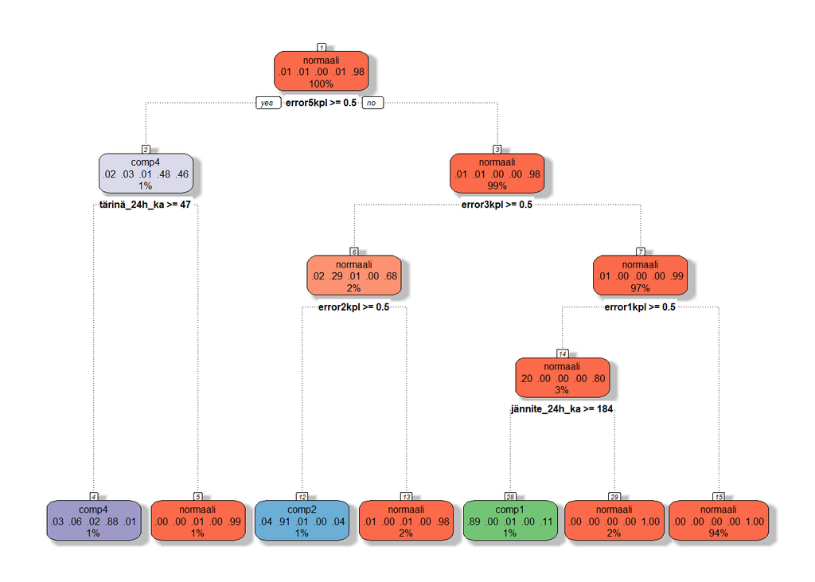

```r
# caret paketin syntaksi#

treeFit = train(training %>% select(one_of(ClassAllFeatures)) %>% as.data.frame(), y = training %>% select(Vika) %>% unlist(), trControl = crossVal, method = "rpart")

fancyRpartPlot(treeFit$finalModel, sub = NULL)
```

```r
treetrainpreds = predict(treeFit, training)
treetestpreds = predict(treeFit, testing)
```

Puussa edetään ylhäältä alas ja jokaisessa laatikossa on kyseiseen päätökseen asti päätyneiden havaintojen todellinen luokkajakauma, sekä laatikon alla seuraavan päätöksen ehto. Alimmalla rivillä on lopullinen päätös mallin mukaisesta luokasta todellisen luokkajakauman kera. Esim. mallin mukaan laite, jolla on ollut enemmän kuin puoli (eli ainakin yksi) tyypin 5 virhe viimeisen 24 tunnin aikana ja tärinän 24 tunnin liukuva keskiarvo on suurempi tai yhtä suuri kuin 47 on vikaantumassa komponentin 4 takia.

Geometrisesti edellä kuvattu alue näyttää tältä.

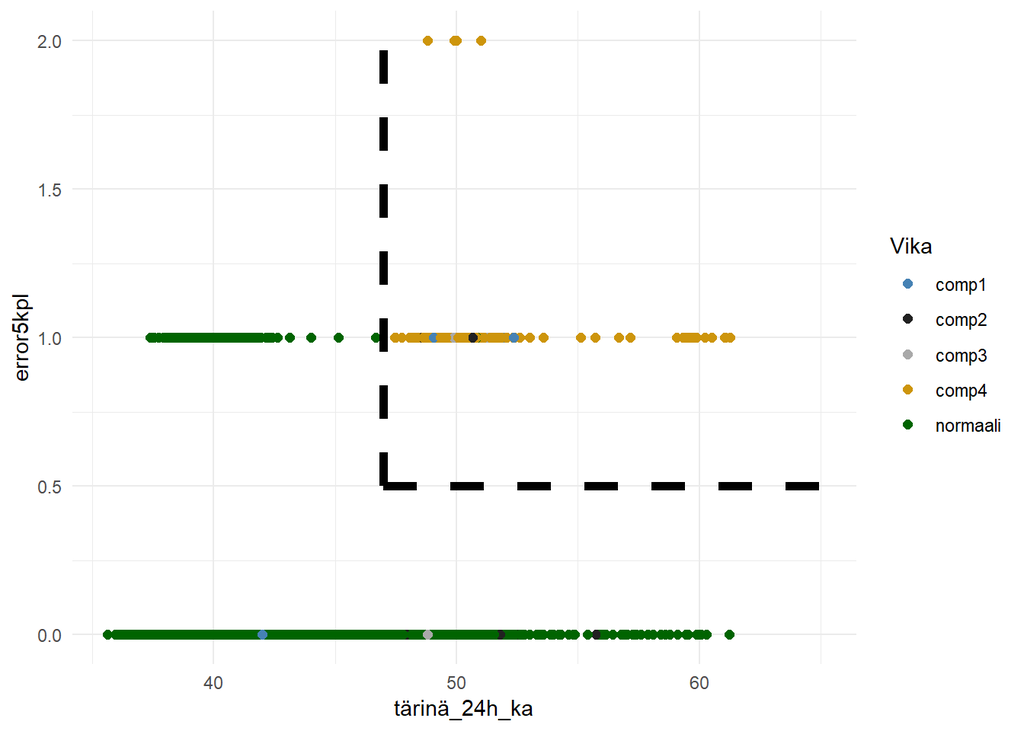

```r
ggplot(training, aes(x = tärinä_24h_ka, y = error5kpl, color = Vika)) +
  geom_point(size = 2) +
  geom_segment(aes(x = 47, xend = 65, y = 0.5, yend = 0.5), size = 2, col = "black", linetype = 2) +
  geom_segment(aes(x = 47, xend = 47, y = 0.5, yend = 2), size = 2, col = "black", linetype = 2) +
  theme_minimal() +
  scale_color_manual(values = custom.col)
```

Silmiinpistävää mallissa on se, ettei se luokittele yhtään havaintoa luokkaan comp3. Kuitenkin se saa opetusdatassa luokittelutarkkuuden 0.9948123. Allaolevassa taulukossa on mallin ennustaman luokan ja todellisen luokan ristiintaulukointi.

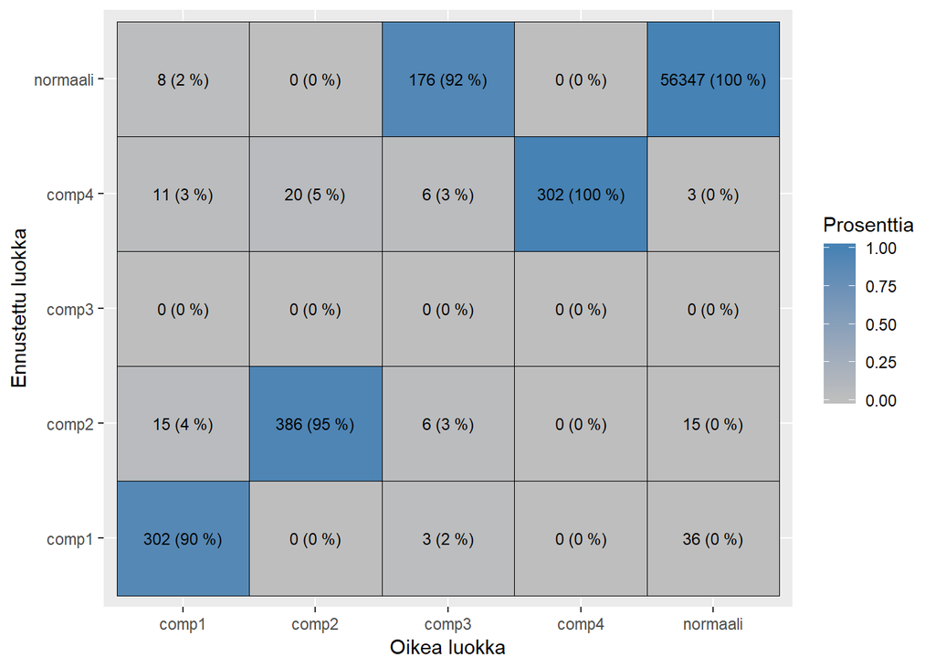

```r
cftree = confusionMatrix(treetrainpreds, training$Vika)
# Ylhäällä tehty oma funktio
plotconf(cftree)
```

Nähdään, että päätöspuumalli luokittelee havaitut luokat “comp4” ja “normaali” pyöristettynä sataprosenttisesti oikein opetusdatassa. Luokat “comp1” ja “comp2” malli luokittelee myös hyvin. Luokka “comp3” menee aina väärin, sillä malli ei luokittelee havaintoa ikinä luokkaan “comp3”. Vääriä hälytyksiä on 0.0936914428482199 % ja huomaamattomia vikoja 0.319244916371712 %.

Testidatassa ennustetarkkuus on 0.9944165 ja ristiintaulukko näyttää hyvin samanlaiselta.

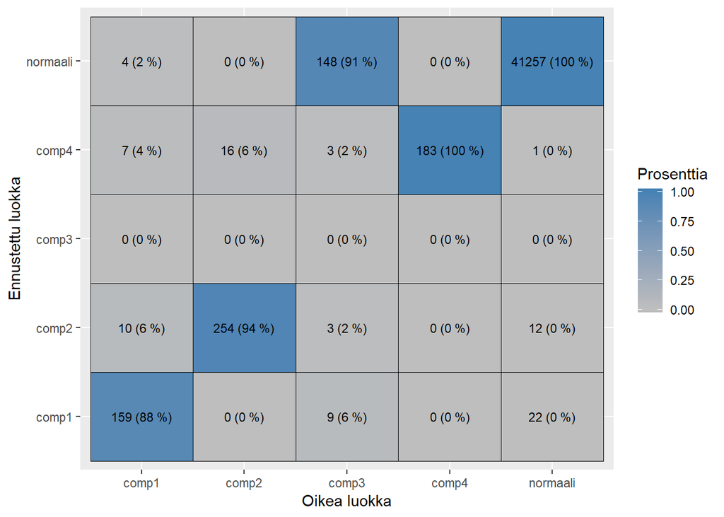

```r
cftree = confusionMatrix(treetestpreds , testing$Vika)
# Ylhäällä tehty oma funktio
plotconf(cftree)
```

Vaikka luokkien “comp1” ja “comp2” tarkkuus on pienentynyt hiukan, voidaan sanoa, että malli yleistyy hyvin ennennäkemättömälle datalle. Testidatassa vääriä hälytyksiä on 0.0831590952290439 % ja huomaamattomia vikoja 0.361148070708991 %.

### 5.0.2 Yleistetty lineaarinen malli

Lineaarisen mallin mukaan selitettävä muuttuja $y$ riippuu lineaarisesti selittävistä muuttujista $x_1$, $x_2$, …, $x_n$. Lineaarisen regression tilanteessa estimoidaan parametrit $\beta_0$, $\beta_1$, $\beta_2$, … $\beta_n$ yhtälölle $y = \beta_0 + \beta_1 x_1 + \beta_2 x_2 + ... + \beta_n x_n$. Luokittelussa mallinnetaan regressiolla havinnon todennäköisyyttä kuulua tiettyyn luokkaan, mutta käytännön syistä mallinnetaan jotain todennäköisyyden $p$ muunnosta kuten nk. *logit* muunnosta $\frac{p}{1-p}$. Tällä periaatteella luotu *logistinen regressiomalli* saa muodon $log(\frac{p}{1-p}) = \beta_0 + \beta_1 x_1 + \beta_2 x_2 + ... + \beta_n x_n$, josta voidaan parametrien estimoimisen jälkeen ratkaista todennäköisyydet $p = \frac{e^{\beta_0 + \beta_1 x_1 + \beta_2 x_2 + ... + \beta_n x_n}}{1+e^{\beta_0 + \beta_1 x_1 + \beta_2 x_2 + ... + \beta_n x_n}}$

```r
logRegGrid = data.frame(decay = c(0, 0.01, 0.1, 0.2, 0.3))
logisticRegressionFit = train(training %>% select(one_of(ClassAllFeatures)) %>% as.data.frame(), y = training %>% select(Vika) %>% unlist(), trControl = crossVal, method = "multinom", tuneGrid = logRegGrid)
logregtrainpreds = predict(logisticRegressionFit, training)
logregtestpreds  = predict(logisticRegressionFit, testing)
```

Logistinen regressiomalli saa luokan “comp2” todennäköisyyden logit muunnoksen osalta selittäville muuttujille $\beta$ parametrit

```r
customDfRender(logisticRegressionFit$finalModel %>% coef() %>% as.data.frame() %>% filter(row_number() == 1), scroll = T)
```

| (Intercept) | jännite_3h_ka | pyörimisnopeus_3h_ka | paine_3h_ka | tärinä_3h_ka | jännite_24h_ka | pyörimisnopeus_24h_ka | paine_24h_ka | tärinä_24h_ka | jännite_3h_sd | pyörimisnopeus_3h_sd | paine_3h_sd | tärinä_3h_sd | jännite_24h_sd | pyörimisnopeus_24h_sd | paine_24h_sd | tärinä_24h_sd | error1kpl | error2kpl | error3kpl | error4kpl | error5kpl | huollostacomp1 | huollostacomp2 | huollostacomp3 | huollostacomp4 | mallimodel2 | mallimodel3 | mallimodel4 | ikä | … |
| --- | --- | --- | --- | --- | --- | --- | --- | --- | --- | --- | --- | --- | --- | --- | --- | --- | --- | --- | --- | --- | --- | --- | --- | --- | --- | --- | --- | --- | --- | --- |
| 5.381049 | -0.0519488 | -0.0011435 | -0.0772998 | -0.1225231 | -0.1172112 | -0.0115289 | 0.1522907 | 0.5419666 | -0.0285709 | 0.0096282 | 0.0058105 | -0.0183186 | 0.0644514 | -0.0661189 | -0.1181313 | 0.527876 | -2.148279 | 3.399533 | 4.707804 | -3.653915 | -1.657439 | 0.0009183 | 0.0159733 | 0.0072144 | 0.0085462 | 0.2999404 | 1.385972 | 2.327171 | 0.1469365 | … |

Malli saa opetusdatassa ennustetarkkuuden 0.9922965 ja ristiintaulukko näyttää tältä

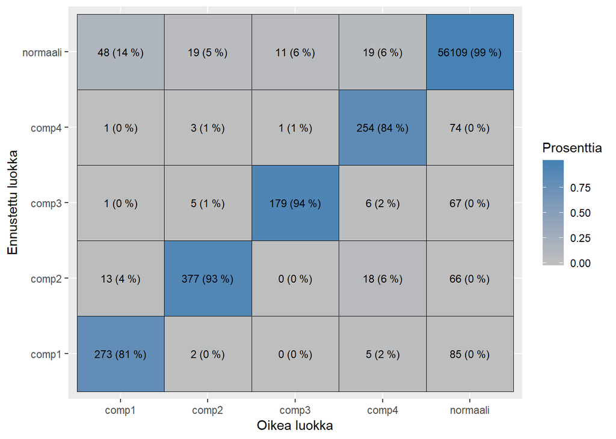

```r
logregconf = confusionMatrix(logregtrainpreds, training$Vika)
plotconf(logregconf)
```

Logistinen regressiomalli pärjää päätöspuuluokittelijalle ainoastaan luokkien “comp2” ja “comp3” ennustamisessa. Vääriä hälytyksiä opetusdatassa on 0.506627802068152 % ja huomaamattomia virheitä 0.168297591782913 %. Erityisesti väärien hälytysten määrä on suuri. Hyvänä puolena logistisessa regressiomallissa on kuitenkin se, että mallista saadaan myös tarvittaessa todennäköisyysarviot jokaiseen luokkaan kuulumiselle.

testidatassa tarkkuus on 0.9940363 ja ristiintaulukko näyttää tältä

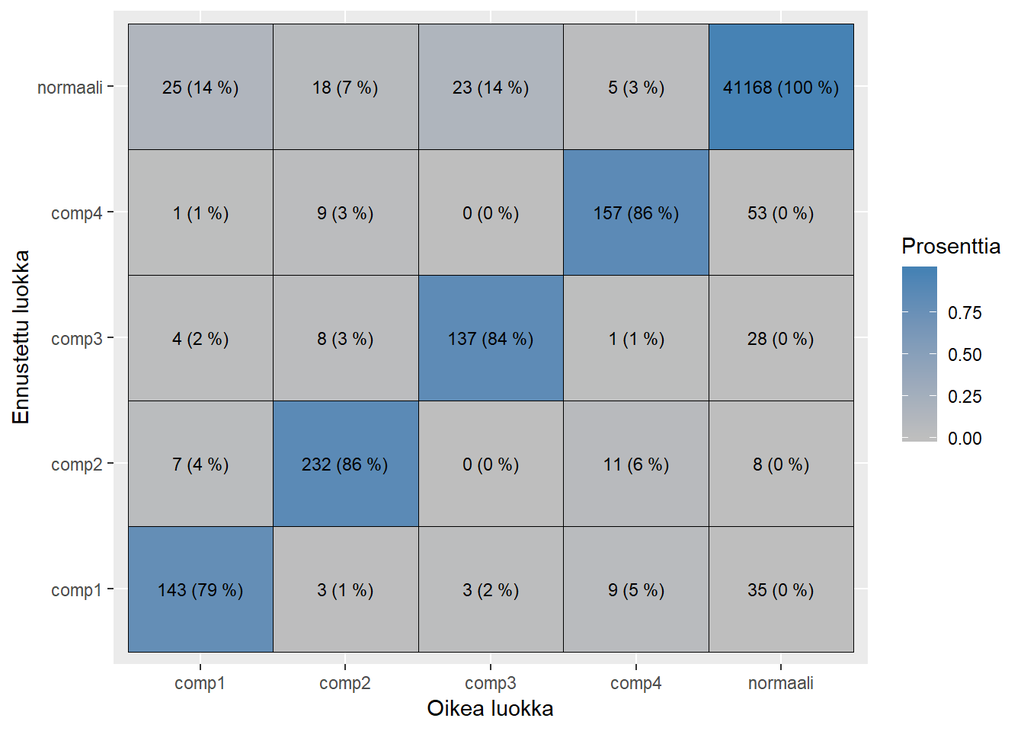

```r
plotconf(confusionMatrix(logregtestpreds, testing$Vika))
```

Vääriä hälytyksiä testidatassa on 0.294620794525756 % ja huomaamattomia virheitä 0.168694164607489 %.

Kaikein kaikkiaan lineaarinen malli ei toimi opetusdatassa erityisen hyvin, eikä myöskään yleisty testidataan riittävän hyvin. Tämä viittaa siihen, ettei selittävien muuttujien vaikutus vikaantumistodennäköisyyksiin ei ole lineaarinen.

### 5.0.3 K:n lähimmän naapurin luokittelija

K:n lähimmän naapurin luokittelija (KNN) luokittelee havainnon siihen luokkaan, mihin sen “lähimmät naapurit” opetusdatassa enimmäkseen kuuluvat. K on mallissa hyperparametri ja viittaa huomioonotettavien naapureiden lukumäärää. Havainnot ovat sitä lähempänä toisiaan, mitä samankaltaisempia niiden selittävien muuttujien arvot ovat.  
KNN vaatii paljon laskentatehoa, koska jokainen havainto täytyy verrata kaikkien muiden kanssa lähimpien naapureiden löytämiseksi. Siksi on järkevää käyttää dimensionpienentämistekniikoita, eli tekniikoita, joilla vähennetään selittävien muuttujien määrää, laskutoimitusten nopeuttamiseksi. Käytetään pääkomponenttianalyysiä, jossa muuttujien määrää pienennetään laskemalla niistä kombinaatioita säilyttäen mahdollisimman suuren osan informaatiosta. Näitä kombinaatioita kutsutaan pääkomponenteiksi.

Tässä opetusdatan kaksi ensimmäistä pääkomponenttia visualisoituna:

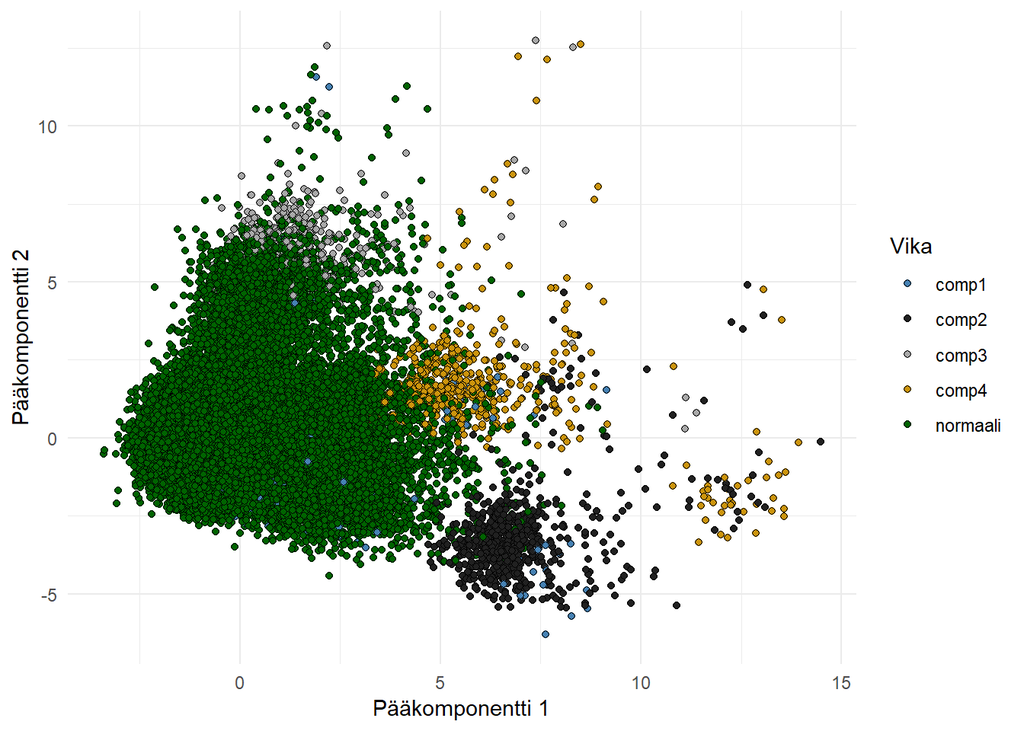

```r
pca = preProcess(training %>% select(one_of(RULAllFeatures)), method = c("center", "scale", "pca"), pcaComp = 2)
trainingpcs = predict(pca, training %>% select(one_of(RULAllFeatures))) %>% mutate(Vika = training$Vika) %>% select(-malli)

kn = train(Vika ~., data = trainingpcs %>% as.data.frame(), method = "knn", tuneGrid = data.frame(k = c(1,3,5,7,9,11,13,15)))
knpreds = predict(kn, trainingpcs)

allpcs = predict(pca, ff)
allpcs = allpcs %>% bind_cols(predict(kn, allpcs, type = "prob")) %>% mutate(Vika = ff$Vika)
ggplot(allpcs, aes(x = PC1, y = PC2, fill = Vika)) +
  geom_point(shape = 21, col = "black") +
  xlab("Pääkomponentti 1") +
  ylab("Pääkomponentti 2") +
  theme_minimal() +
  scale_fill_manual(values = custom.col)
```

Tähän kaksiulotteiseen dataan sovitettu KNN saa opetustarkkuuden 0.9889305. Alla ristiinvalidoitu opetustarkkuus eri K:n arvoilla:

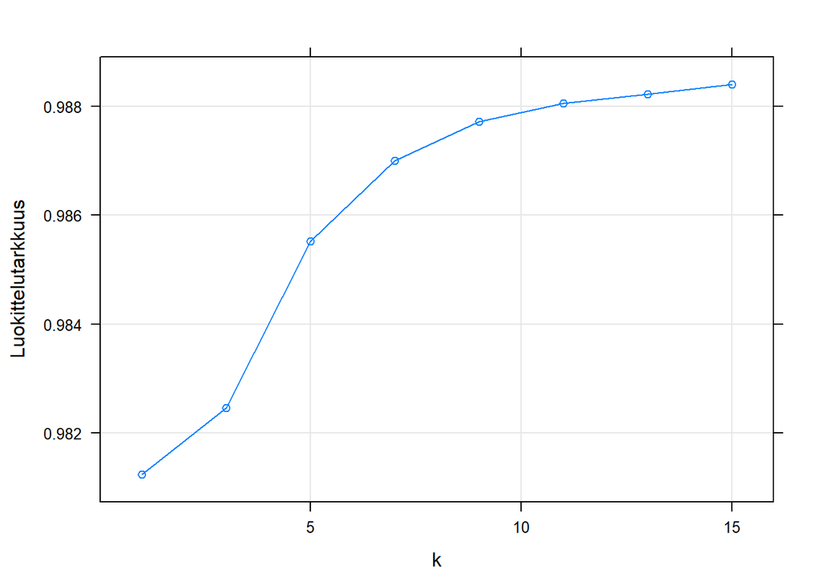

```r
plot(kn, xlab = "k", ylab = "Luokittelutarkkuus")
```

Paras K:n arvo oli 15

Alla oleva kuva havainnollistaa, mihin luokkaan KNN luokittelee havainnon pääkomponenttien perusteella eri k:n arvoilla, eli ns. päätösalueet:

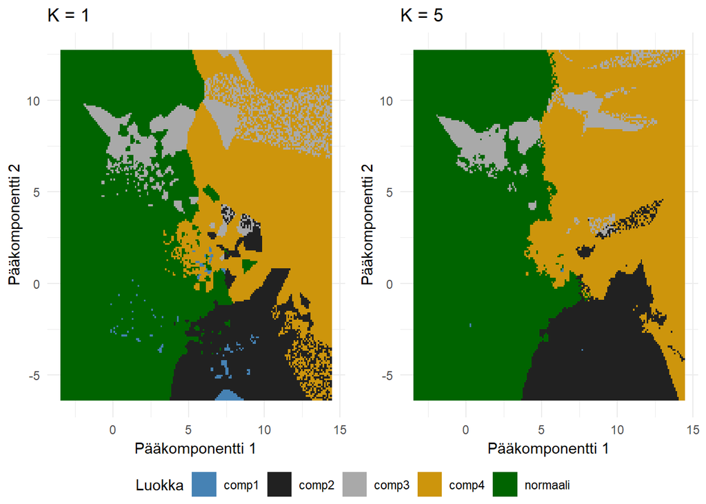

```r
pcgrid = expand.grid(PC1 = seq(min(allpcs$PC1),max(allpcs$PC1),0.1), PC2 = seq(min(allpcs$PC2),max(allpcs$PC2),0.1))
gridpredsk1 = knn(trainingpcs %>% select(PC1, PC2), pcgrid, trainingpcs$Vika, k = 1)
gridpredsk5 = knn(trainingpcs %>% select(PC1, PC2), pcgrid, trainingpcs$Vika, k = 5)
gridpredsk9 = knn(trainingpcs %>% select(PC1, PC2), pcgrid, trainingpcs$Vika, k = 9)
gridpredsk13 = knn(trainingpcs %>% select(PC1, PC2), pcgrid, trainingpcs$Vika, k = 13)

pcgrid = pcgrid %>% mutate(Luokka = gridpredsk1)
g1 = ggplot(pcgrid, aes(x = PC1, y = PC2, colour = Luokka, fill = Luokka)) +
  geom_tile() +
  xlab("Pääkomponentti 1") +
  ylab("Pääkomponentti 2") +
  ggtitle("K = 1") +
  theme_minimal() +
  scale_color_manual(values = custom.col, drop = F) +
  scale_fill_manual(values = custom.col, drop = F)


pcgrid = pcgrid %>% mutate(Luokka = gridpredsk5)
g2 = ggplot(pcgrid, aes(x = PC1, y = PC2, colour = Luokka, fill = Luokka)) +
  geom_tile() +
  xlab("Pääkomponentti 1") +
  ylab("Pääkomponentti 2") +
  ggtitle("K = 5") +
  theme_minimal() +
  scale_color_manual(values = custom.col, drop = F) +
  scale_fill_manual(values = custom.col, drop = F)

pcgrid = pcgrid %>% mutate(Luokka = gridpredsk9)
g3 = ggplot(pcgrid, aes(x = PC1, y = PC2, colour = Luokka, fill = Luokka)) +
  geom_tile() +
  xlab("Pääkomponentti 1") +
  ylab("Pääkomponentti 2") +
  ggtitle("K = 9") +
  theme_minimal() +
  scale_color_manual(values = custom.col, drop = F) +
  scale_fill_manual(values = custom.col, drop = F)

pcgrid = pcgrid %>% mutate(Luokka = gridpredsk13)
g4 = ggplot(pcgrid, aes(x = PC1, y = PC2, colour = Luokka, fill = Luokka)) +
  geom_tile() +
  xlab("Pääkomponentti 1") +
  ylab("Pääkomponentti 2") +
  ggtitle("K = 13") +
  theme_minimal() +
  scale_color_manual(values = custom.col, drop = F) +
  scale_fill_manual(values = custom.col, drop = F)



ggarrange(g1,g2, ncol = 2, nrow = 1, common.legend = T, legend = "bottom")
```

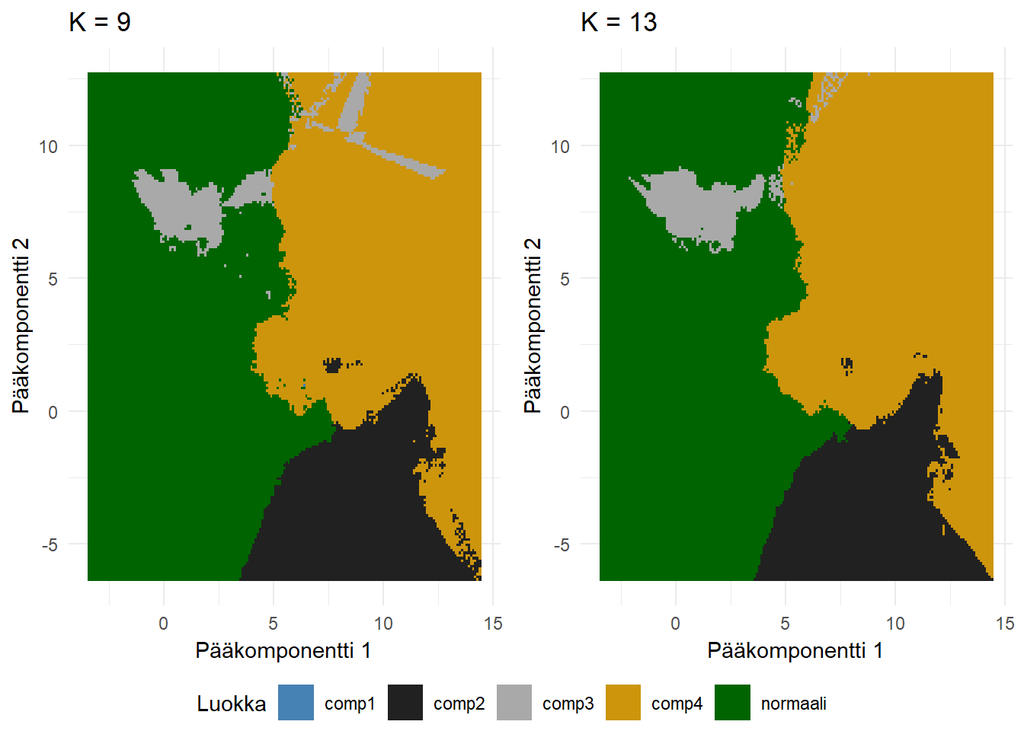

```r
ggarrange(g3,g4, ncol = 2, nrow = 1, common.legend = T, legend = "bottom")
```

Alla kuva optimaalisella k:n arvolla 15 opetusdatan pisteiden kera:

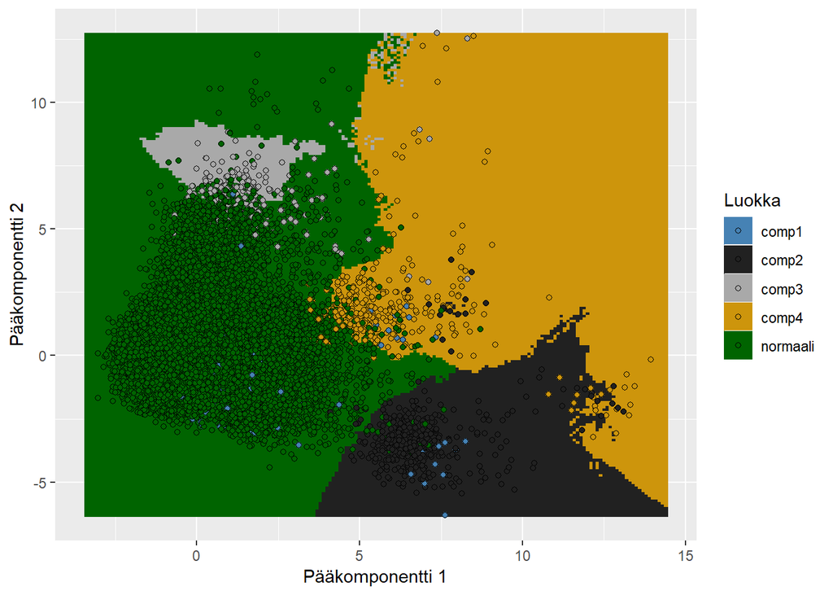

```r
gridpreds = predict(kn, pcgrid)
pcgrid = pcgrid %>% mutate(Luokka = gridpreds)
ggplot(pcgrid, aes(x = PC1, y = PC2, colour = Luokka, fill = Luokka)) +
  geom_tile() +
  geom_point(data = trainingpcs %>% mutate(Luokka = Vika), col = "black", shape = 21)+
  xlab("Pääkomponentti 1") +
  ylab("Pääkomponentti 2") +
  scale_fill_manual(values = custom.col, drop = F) +
  scale_color_manual(values = custom.col, drop = F)
```

ja testidatan pisteiden kera:

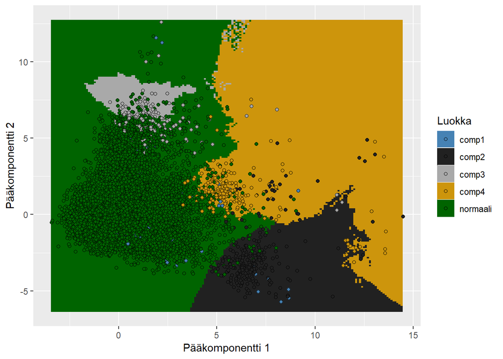

```r
testingpcs = predict(pca, testing %>% select(one_of(RULAllFeatures))) %>% mutate(Vika = testing$Vika) %>% select(-malli)

ggplot(pcgrid, aes(x = PC1, y = PC2, colour = Luokka, fill = Luokka)) +
  geom_tile() +
  geom_point(data = testingpcs %>% mutate(Luokka = Vika), col = "black", shape = 21)+
  xlab("Pääkomponentti 1") +
  ylab("Pääkomponentti 2") +
  scale_fill_manual(values = custom.col, drop = F) +
  scale_color_manual(values = custom.col, drop = F)
```

```r
kntestpreds = predict(kn, testingpcs)
```

Testidatassa luokittelutarkkuus on 0.9883577

```r
knnstart = Sys.time()
pcapp = preProcess(training %>% select(one_of(ClassAllFeatures)), method = c("center", "scale", "pca"), pcaComp = 10)
knnGrid = data.frame(k = c(3,5,7,9,11,13))
knnFit = train(Vika ~., predict(pcapp, training %>% select(one_of(ClassAllFeatures))) %>% mutate(Vika = training$Vika, Malli = training$malli) %>% as.data.frame(), trControl = crossVal, method = "knn", tuneGrid = knnGrid)
knntrainpreds = predict(knnFit, predict(pcapp,training %>% select(one_of(ClassAllFeatures)) %>% mutate(Malli = training$malli)))

knntestpreds = predict(knnFit, predict(pcapp,testing %>% select(one_of(ClassAllFeatures)) %>% mutate(Malli = testing$malli)))
knntime = difftime(Sys.time(), knnstart, units = "mins")
```

Kaksiulotteiseen avaruuteen sovitettaessa tulosten tulkittavuus ja visualisointi on helpompaa, mutta menetetään väkisinkin paljon informaatiota. Tehdään sovitus myös kymmeneen ensimmäiseen pääkomponenttiin. Tällöin luokittelutaarkkuus eri K:n arvoilla näyttää tältä.

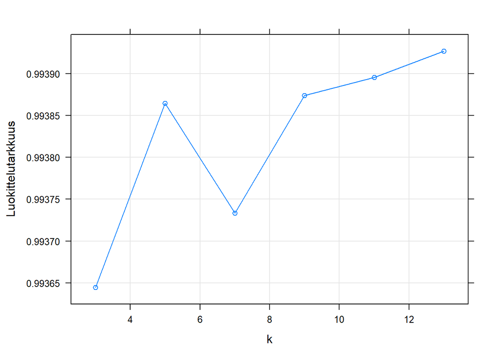

```r
plot(knnFit, xlab = "k", ylab = "Luokittelutarkkuus")
```

Optimaalinen k:n arvo opetusdatassa on 13 ja sillä saavutetaan opetusdatassa luokittelutarkkuus 0.9956277. Dimensioiden lisääminen paransi tarkkuutta selvästi, joten käytetään kymmentä dimensiota. Ristiintaulukko näyttää tältä.

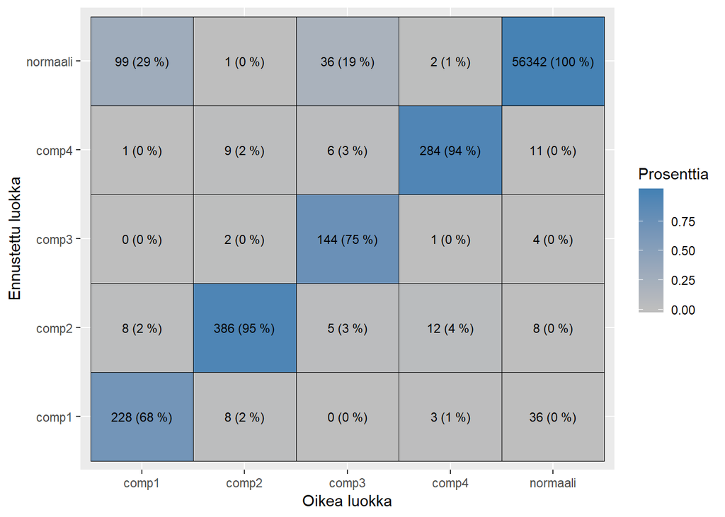

```r
plotconf(confusionMatrix(knntrainpreds, training$Vika))
```

Vääriä hälytyksiä opetusdatassa on 0.102366576445277 % ja huomaamattomia virheitä 0.239433687278784 %

Testidatassa luokittelutarkkuus on 0.9944877 ja ristiintaulukko näyttää tältä

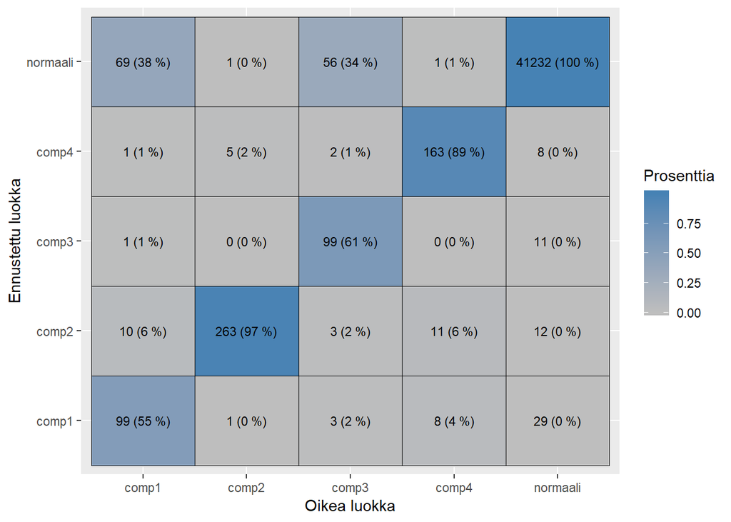

```r
plotconf(confusionMatrix(knntestpreds, testing$Vika))
```

```r
knntestacc = postResample(knntestpreds, testing$Vika)
knntrainacc = postResample(knntrainpreds, training$Vika)
```

Vääriä hälytyksiä testidatassa on 0.142558448964075 % ja huomaamattomia virheitä 0.301748716973959 %

### 5.0.4 Boosting-menetelmä

Boosting menetelmässä opetetaan useita “heikkoja” malleja, kuten päätöspuita käyttäen opetusdatan eri osajoukkoja ja niiden tulokset yhdistetään yhdeksi vahvaksi malliksi. Hyperparametreina mallissa toimii puiden määrä ja puun maksimisyvyys.

```r
gbmFit = train(training %>% select(one_of(ClassAllFeatures)) %>% as.data.frame(), y = training %>% select(Vika) %>% unlist(), trControl = crossVal, method = "gbm")
gbmtrainpreds = predict(gbmFit, training)
gbmtestpreds = predict(gbmFit, testing)
```

Boosting menetelmän ristiinvalidoitu luokittelutarkkuus eri hyperparametrien arvoilla.

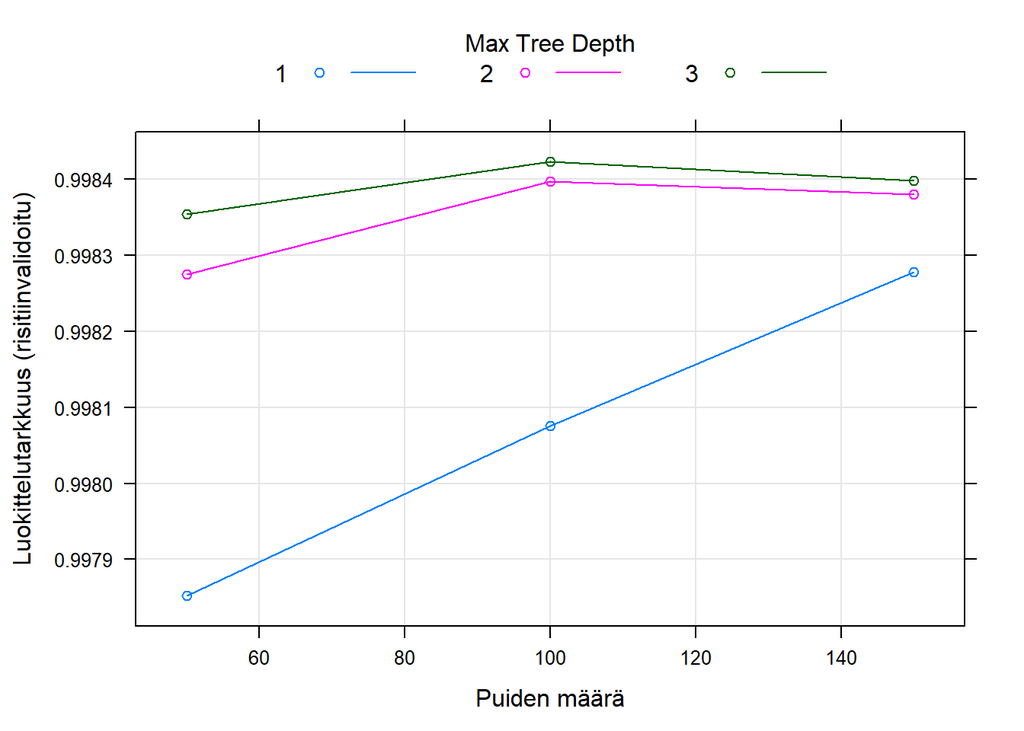

```r
plot(gbmFit, xlab = c("Puiden määrä"), ylab = c("Luokittelutarkkuus (risitiinvalidoitu)"), )
```

Boostattu päätöspuumalli saa opetusdatassa tarkkuuden 0.9995836 ja sen ristiintaulukko näyttää tältä

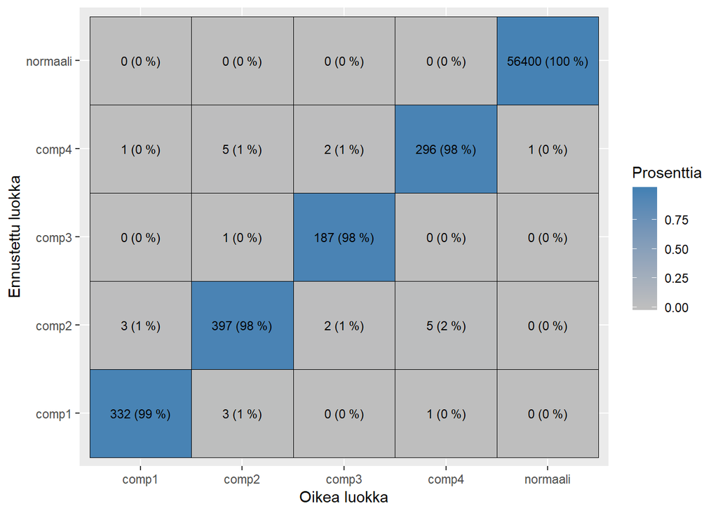

```r
plotconf(confusionMatrix(gbmtrainpreds, training$Vika))
```

Vääriä hälytyksiä opetusdatassa on 0.00173502671941148 % ja huomaamattomia virheitä 0 %

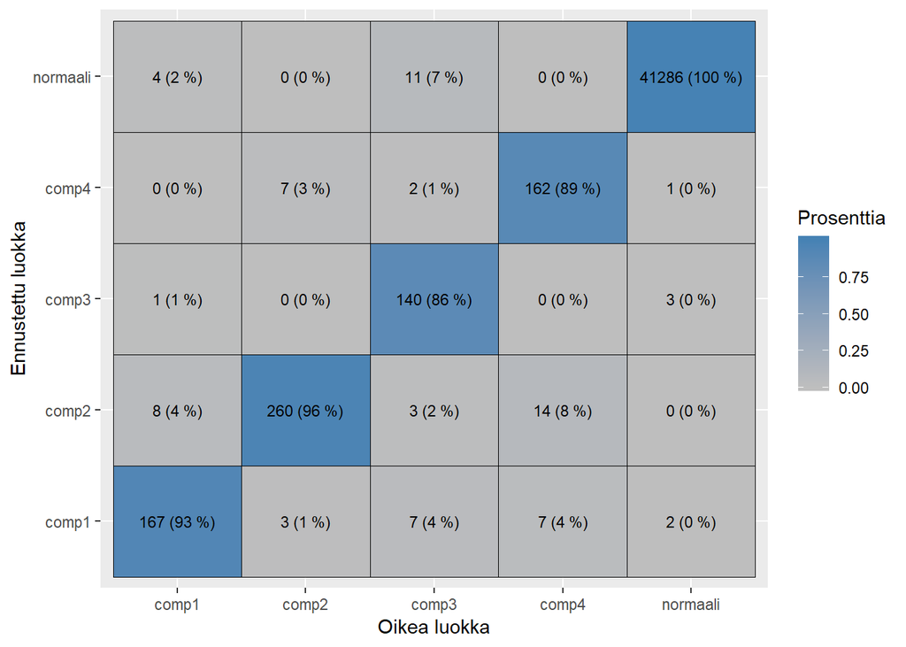

```r
plotconf(confusionMatrix(gbmtestpreds, testing$Vika))
```

Vääriä hälytyksiä testidatassa on 0.0142558448964075 % ja huomaamattomia virheitä 0.0356396122410188 %.

### 5.0.5 Yhteenveto

```r
summ = matrix(nrow = 5, ncol = 3, data = c("Päätöspuu", postResample(treetrainpreds, training$Vika)[1], postResample(treetestpreds, testing$Vika)[1],"Logistinen regressio", postResample(logregtrainpreds, training$Vika)[1], postResample(logregtrainpreds, testing$Vika)[1], "KNN", knntrainacc[1], knntestacc[1], "Boostattu päätöspuu", postResample(gbmtrainpreds, training$Vika)[1], postResample(gbmtestpreds, testing$Vika)[1], "Nollamalli", nrow(training %>% filter(Vika == "normaali"))/nrow(training), nrow(testing %>% filter(Vika == "normaali"))/nrow(testing)), byrow = T)
colnames(summ) = c("Malli", "Opetustarkkuus", "Testitarkkuus")
summ %>% as.data.frame(stringsAsFactors = F) %>% arrange(Testitarkkuus) %>% customDfRender()
```

[output not shown]

Käytetyistä malleista parhaan tarkkuuden testidatassa saavutti boostattu päätöspuuluokittelija, joka pystyy ennustamaan laitteen hajoamisen 24 tuntia etukäteen n. 0.9982655 tarkkuudella. Malli on riittävän tarkka teolliseen käyttöönottoon, sillä varsinkin huomaamattomien virheiden määrä on alhainen.

# 6 Lähteet

https://gallery.azure.ai/Notebook/Predictive-Maintenance-Modelling-Guide-R-Notebook-1 https://docs.microsoft.com/en-us/azure/machine-learning/team-data-science-process/cortana-analytics-playbook-predictive-maintenance